# Analysis of Football Players

### Group: Group 1

### Team: Avinash Kumar, Vamsi Krishna, Vishwas Narayan

### Project: Digital Tools for Strategic Planning (DOORSTEP)

Import Statements for data analysis using pandas, data manipulation using numpy and plotting the visualizations such as choropleth map, line plots, horizontal barplots using plotly, matplotlib and seaborn.

```python
# Pandas libraries
import pandas as pd
import pandasql as ps
import pandas_profiling as pp
import numpy as np
from collections import OrderedDict
import re

# Visualization libraries
import matplotlib.pyplot as plt
import seaborn as sns
import matplotlib.patches as mpatches
import plotly.offline as py
import plotly.express as px
import plotly.graph_objs as go
from plotly import tools
from plotly.offline import download_plotlyjs, init_notebook_mode, plot, iplot
import warnings
warnings.filterwarnings('ignore')
sns.set_style(style='darkgrid')
init_notebook_mode(connected=True)

from sklearn.cluster import KMeans
from sklearn.metrics import silhouette_score
from sklearn.preprocessing import StandardScaler
```

## Exploratory and Data Analysis

#### Reading the Dataset on FIFA-19

##### data:

This dataset includes details about different football players featured in EA's FIFA 19.

##### positions:

This dataset includes detailed information about the different positions with its full names on a football field.

```python
#reading the dataframe
data = pd.read_excel('2021-06-23_Dataset_Fifa_19.xlsx')
positions = pd.read_excel('fifa19_positions.xlsx')
```

```python
display(data.head())
display(data.info())
display(data.describe())
display(positions)
```

|  | Order | ID | Name | Age | Photo | Nationality | Flag | Overall | Potential | Club | ... | Composure | Marking | StandingTackle | SlidingTackle | GKDiving | GKHandling | GKKicking | GKPositioning | GKReflexes | Release Clause |
| --- | --- | --- | --- | --- | --- | --- | --- | --- | --- | --- | --- | --- | --- | --- | --- | --- | --- | --- | --- | --- | --- |
| 0 | 0 | 158023 | L. Messi | 31 | https://cdn.sofifa.org/players/4/19/158023.png | Argentina | https://cdn.sofifa.org/flags/52.png | 94 | 94 | FC Barcelona | ... | 96.0 | 33.0 | 28.0 | 26.0 | 6.0 | 11.0 | 15.0 | 14.0 | 8.0 | €226.5M |
| 1 | 1 | 20801 | Cristiano Ronaldo | 33 | https://cdn.sofifa.org/players/4/19/20801.png | Portugal | https://cdn.sofifa.org/flags/38.png | 94 | 94 | Juventus | ... | 95.0 | 28.0 | 31.0 | 23.0 | 7.0 | 11.0 | 15.0 | 14.0 | 11.0 | €127.1M |
| 2 | 2 | 190871 | Neymar Jr | 26 | https://cdn.sofifa.org/players/4/19/190871.png | Brazil | https://cdn.sofifa.org/flags/54.png | 92 | 93 | Paris Saint-Germain | ... | 94.0 | 27.0 | 24.0 | 33.0 | 9.0 | 9.0 | 15.0 | 15.0 | 11.0 | €228.1M |
| 3 | 3 | 193080 | De Gea | 27 | https://cdn.sofifa.org/players/4/19/193080.png | Spain | https://cdn.sofifa.org/flags/45.png | 91 | 93 | Manchester United | ... | 68.0 | 15.0 | 21.0 | 13.0 | 90.0 | 85.0 | 87.0 | 88.0 | 94.0 | €138.6M |
| 4 | 4 | 192985 | K. De Bruyne | 27 | https://cdn.sofifa.org/players/4/19/192985.png | Belgium | https://cdn.sofifa.org/flags/7.png | 91 | 92 | Manchester City | ... | 88.0 | 68.0 | 58.0 | 51.0 | 15.0 | 13.0 | 5.0 | 10.0 | 13.0 | €196.4M |

5 rows × 89 columns

```
<class 'pandas.core.frame.DataFrame'>
RangeIndex: 18207 entries, 0 to 18206
Data columns (total 89 columns):
 #   Column                    Non-Null Count  Dtype
---  ------                    --------------  -----
 0   Order                     18207 non-null  int64
 1   ID                        18207 non-null  int64
 2   Name                      18207 non-null  object
 3   Age                       18207 non-null  int64
 4   Photo                     18207 non-null  object
 5   Nationality               18207 non-null  object
 6   Flag                      18207 non-null  object
 7   Overall                   18207 non-null  int64
 8   Potential                 18207 non-null  int64
 9   Club                      17966 non-null  object
```

[output cut: 81 more lines]

```
None
```

|  | Order | ID | Age | Overall | Potential | Special | International Reputation | Weak Foot | Skill Moves | Jersey Number | ... | Penalties | Composure | Marking | StandingTackle | SlidingTackle | GKDiving | GKHandling | GKKicking | GKPositioning | GKReflexes |
| --- | --- | --- | --- | --- | --- | --- | --- | --- | --- | --- | --- | --- | --- | --- | --- | --- | --- | --- | --- | --- | --- |
| count | 18207.000000 | 18207.000000 | 18207.000000 | 18207.000000 | 18207.000000 | 18179.000000 | 18131.000000 | 18131.000000 | 18131.000000 | 18119.000000 | ... | 18131.000000 | 18131.000000 | 18131.000000 | 18131.000000 | 18131.000000 | 18131.000000 | 18131.000000 | 18131.000000 | 18131.000000 | 18131.000000 |
| mean | 9103.000000 | 214298.338606 | 25.122206 | 66.238699 | 71.307299 | 1597.947907 | 1.113397 | 2.947217 | 2.361701 | 19.544401 | ... | 48.560807 | 58.658541 | 47.276212 | 47.697149 | 45.660030 | 16.618057 | 16.393194 | 16.231758 | 16.390822 | 16.710937 |
| std | 5256.052511 | 29965.244204 | 4.669943 | 6.908930 | 6.136496 | 272.585019 | 0.394310 | 0.660462 | 0.756292 | 15.952570 | ... | 15.706617 | 11.432878 | 19.909676 | 21.670806 | 21.296616 | 17.697405 | 16.909519 | 16.503546 | 17.037065 | 17.960529 |
| min | 0.000000 | 16.000000 | 16.000000 | 46.000000 | 48.000000 | 731.000000 | 1.000000 | 1.000000 | 1.000000 | 1.000000 | ... | 5.000000 | 3.000000 | 3.000000 | 2.000000 | 3.000000 | 1.000000 | 1.000000 | 1.000000 | 1.000000 | 1.000000 |
| 25% | 4551.500000 | 200315.500000 | 21.000000 | 62.000000 | 67.000000 | 1458.000000 | 1.000000 | 3.000000 | 2.000000 | 8.000000 | ... | 39.000000 | 51.000000 | 30.000000 | 27.000000 | 24.000000 | 8.000000 | 8.000000 | 8.000000 | 8.000000 | 8.000000 |
| 50% | 9103.000000 | 221759.000000 | 25.000000 | 66.000000 | 71.000000 | 1635.000000 | 1.000000 | 3.000000 | 2.000000 | 17.000000 | ... | 49.000000 | 60.000000 | 53.000000 | 55.000000 | 52.000000 | 11.000000 | 11.000000 | 11.000000 | 11.000000 | 11.000000 |
| 75% | 13654.500000 | 236529.500000 | 28.000000 | 71.000000 | 75.000000 | 1787.000000 | 1.000000 | 3.000000 | 3.000000 | 26.000000 | ... | 60.000000 | 67.000000 | 64.000000 | 66.000000 | 64.000000 | 14.000000 | 14.000000 | 14.000000 | 14.000000 | 14.000000 |
| max | 18206.000000 | 246620.000000 | 45.000000 | 94.000000 | 95.000000 | 2346.000000 | 5.000000 | 5.000000 | 5.000000 | 99.000000 | ... | 92.000000 | 96.000000 | 94.000000 | 93.000000 | 91.000000 | 90.000000 | 92.000000 | 91.000000 | 90.000000 | 94.000000 |

8 rows × 44 columns

|  | Position | Description | Zone |
| --- | --- | --- | --- |
| 0 | GK | Goal Keeper | GoalKeeper |
| 1 | CB | Centre Back | Defense |
| 2 | LCB | Left Centre Back | Defense |
| 3 | RCB | Right Centre Back | Defense |
| 4 | LB | Left Back | Defense |
| 5 | RB | Right Back | Defense |
| 6 | LWB | Left Wing Back | Defense |
| 7 | RWB | Right Wing Back | Defense |
| 8 | CDM | Centre Defensive Midfielder | Midfield |
| 9 | LDM | Left Defensive Midfielder | Midfield |
| 10 | RDM | Right Defensive Midfielder | Midfield |
| 11 | CM | Centre Midfielder | Midfield |
| 12 | LCM | Left Centre Midfielder | Midfield |
| 13 | RCM | Right Centre Midfielder | Midfield |
| 14 | LM | Left Midfielder | Midfield |
| 15 | RM | Right Midfielder | Midfield |
| 16 | CAM | Centre Attacking Midfielder | Midfield |
| 17 | LAM | Left Attacking Midfielder | Midfield |
| 18 | RAM | Right Attacking Midfielder | Midfield |
| 19 | LW | Left Winger | Midfield |
| 20 | RW | Right Winger | Midfield |
| 21 | CF | Centre Fordward | Attack |
| 22 | LF | Left Fordward | Attack |
| 23 | RF | Right Forward | Attack |
| 24 | ST | Striker | Attack |
| 25 | LS | Left Striker | Attack |
| 26 | RS | Right Striker | Attack |

### Replacing nan values with mean of columns

As we will be using the numerical columns in further analysis like calculating defensive score for every club, we are replacing null values in columns with mean of the column.

```python
#filling the missing values for the continous variables for proper data visualization

data['ShortPassing'].fillna(data['ShortPassing'].mean(), inplace = True)
data['Volleys'].fillna(data['Volleys'].mean(), inplace = True)
data['Dribbling'].fillna(data['Dribbling'].mean(), inplace = True)
data['Curve'].fillna(data['Curve'].mean(), inplace = True)
data['FKAccuracy'].fillna(data['FKAccuracy'].mean(), inplace = True)
data['LongPassing'].fillna(data['LongPassing'].mean(), inplace = True)
data['BallControl'].fillna(data['BallControl'].mean(), inplace = True)
data['HeadingAccuracy'].fillna(data['HeadingAccuracy'].mean(), inplace = True)
data['Finishing'].fillna(data['Finishing'].mean(), inplace = True)
data['Crossing'].fillna(data['Crossing'].mean(), inplace = True)
#data['Weight'].fillna('200lbs', inplace = True)
data['Contract Valid Until'].fillna(2019, inplace = True)
#data['Height'].fillna("5'11", inplace = True)
data['Loaned From'].fillna('None', inplace = True)
data['Joined'].fillna('Jul 1, 2018', inplace = True)
data['Jersey Number'].fillna(8, inplace = True)
data['Body Type'].fillna('Normal', inplace = True)
data['Position'].fillna('ST', inplace = True)
data['Club'].fillna('No Club', inplace = True)
data['Work Rate'].fillna('Medium/ Medium', inplace = True)
data['Skill Moves'].fillna(data['Skill Moves'].median(), inplace = True)
data['Weak Foot'].fillna(3, inplace = True)
data['Preferred Foot'].fillna('Right', inplace = True)
data['International Reputation'].fillna(1, inplace = True)
data['Wage'].fillna('€200K', inplace = True)
data.fillna(0, inplace = True)
```

```python
data[data['Club']=="No Club"]
```

|  | Order | ID | Name | Age | Photo | Nationality | Flag | Overall | Potential | Club | ... | Composure | Marking | StandingTackle | SlidingTackle | GKDiving | GKHandling | GKKicking | GKPositioning | GKReflexes | Release Clause |
| --- | --- | --- | --- | --- | --- | --- | --- | --- | --- | --- | --- | --- | --- | --- | --- | --- | --- | --- | --- | --- | --- |
| 452 | 452 | 207439 | L. Paredes | 24 | https://cdn.sofifa.org/players/4/19/207439.png | Argentina | https://cdn.sofifa.org/flags/52.png | 80 | 85 | No Club | ... | 74.0 | 73.0 | 75.0 | 72.0 | 9.0 | 14.0 | 6.0 | 9.0 | 10.0 | 0 |
| 538 | 538 | 156713 | A. Granqvist | 33 | https://cdn.sofifa.org/players/4/19/156713.png | Sweden | https://cdn.sofifa.org/flags/46.png | 80 | 80 | No Club | ... | 78.0 | 82.0 | 83.0 | 79.0 | 7.0 | 9.0 | 12.0 | 10.0 | 15.0 | 0 |
| 568 | 568 | 229909 | A. Lunev | 26 | https://cdn.sofifa.org/players/4/19/229909.png | Russia | https://cdn.sofifa.org/flags/40.png | 79 | 81 | No Club | ... | 69.0 | 18.0 | 20.0 | 12.0 | 80.0 | 73.0 | 65.0 | 77.0 | 85.0 | 0 |
| 677 | 677 | 187347 | I. Smolnikov | 29 | https://cdn.sofifa.org/players/4/19/187347.png | Russia | https://cdn.sofifa.org/flags/40.png | 79 | 79 | No Club | ... | 73.0 | 76.0 | 76.0 | 80.0 | 7.0 | 12.0 | 10.0 | 8.0 | 15.0 | 0 |
| 874 | 874 | 187607 | A. Dzyuba | 29 | https://cdn.sofifa.org/players/4/19/187607.png | Russia | https://cdn.sofifa.org/flags/40.png | 78 | 78 | No Club | ... | 70.0 | 21.0 | 15.0 | 19.0 | 15.0 | 12.0 | 11.0 | 11.0 | 8.0 | 0 |
| ... | ... | ... | ... | ... | ... | ... | ... | ... | ... | ... | ... | ... | ... | ... | ... | ... | ... | ... | ... | ... | ... |
| 17197 | 17197 | 245164 | V. Kaith | 21 | https://cdn.sofifa.org/players/4/19/245164.png | India | https://cdn.sofifa.org/flags/159.png | 55 | 64 | No Club | ... | 29.0 | 8.0 | 12.0 | 11.0 | 55.0 | 50.0 | 57.0 | 59.0 | 53.0 | 0 |
| 17215 | 17215 | 243131 | K. Taimi | 26 | https://cdn.sofifa.org/players/4/19/243131.png | Finland | https://cdn.sofifa.org/flags/17.png | 55 | 57 | No Club | ... | 36.0 | 51.0 | 58.0 | 64.0 | 11.0 | 9.0 | 9.0 | 12.0 | 12.0 | 0 |
| 17339 | 17339 | 233526 | S. Passi | 23 | https://cdn.sofifa.org/players/4/19/233526.png | India | https://cdn.sofifa.org/flags/159.png | 54 | 63 | No Club | ... | 45.0 | 14.0 | 23.0 | 21.0 | 8.0 | 6.0 | 13.0 | 9.0 | 10.0 | 0 |
| 17436 | 17436 | 236452 | D. Lalhlimpuia | 20 | https://cdn.sofifa.org/players/4/19/236452.png | India | https://cdn.sofifa.org/flags/159.png | 54 | 67 | No Club | ... | 46.0 | 26.0 | 17.0 | 13.0 | 7.0 | 8.0 | 12.0 | 11.0 | 11.0 | 0 |
| 17539 | 17539 | 234508 | C. Singh | 21 | https://cdn.sofifa.org/players/4/19/234508.png | India | https://cdn.sofifa.org/flags/159.png | 53 | 62 | No Club | ... | 41.0 | 56.0 | 49.0 | 53.0 | 12.0 | 9.0 | 6.0 | 14.0 | 8.0 | 0 |

241 rows × 89 columns

### Slicing the dataframe to exclude the rows where players do not have clubs assigned to them

It is a necessary step since we will be caluclating the defensive score of every club in order to find the club with lowest affinity for concending the goals. Players who have No club will be redundant. Therefore, we have removed those columns

```python
data=data[data.Club!='No Club']
```

### Caluclating the overall personality of players.

```python
def defending(data):
    return int(round((data[['Marking', 'StandingTackle', 'SlidingTackle']].mean()).mean()))

def general(data):
    return int(round((data[['HeadingAccuracy', 'Dribbling', 'Curve', 'BallControl']].mean()).mean()))

def mental(data):
    return int(round((data[['Aggression', 'Interceptions', 'Positioning', 'Vision', 'Composure']].mean()).mean()))

def passing(data):
    return int(round((data[['Crossing', 'ShortPassing', 'LongPassing']].mean()).mean()))

def mobility(data):
    return int(round((data[['Acceleration', 'SprintSpeed', 'Agility', 'Reactions']].mean()).mean()))

def power(data):
    return int(round((data[['Balance', 'Jumping', 'Stamina', 'Strength']].mean()).mean()))

def rating(data):
    return int(round((data[['Potential', 'Overall']].mean()).mean()))

def shooting(data):
    return int(round((data[['Finishing', 'Volleys', 'FKAccuracy', 'ShotPower', 'LongShots', 'Penalties']].mean()).mean()))
```

```python
#renaming a column

data.rename(columns = {'Club Logo': 'Club_Logo'}, inplace = True)

#adding these categories to the data

data['Defending'] = data.apply(defending, axis = 1)
data['General'] = data.apply(general, axis = 1)
data['Mental'] = data.apply(mental, axis = 1)
data['Passing'] = data.apply(passing, axis = 1)
data['Mobility'] = data.apply(mobility, axis = 1)
data['Power'] = data.apply(power, axis = 1)
data['Rating'] = data.apply(rating, axis = 1)
data['Shooting'] = data.apply(shooting, axis = 1)

players = data[['Name', 'Defending', 'General', 'Mental', 'Passing',
                'Mobility', 'Power', 'Rating', 'Shooting', 'Flag', 'Age',
                'Nationality', 'Photo', 'Club_Logo', 'Club']]

players.head()
```

|  | Name | Defending | General | Mental | Passing | Mobility | Power | Rating | Shooting | Flag | Age | Nationality | Photo | Club_Logo | Club |
| --- | --- | --- | --- | --- | --- | --- | --- | --- | --- | --- | --- | --- | --- | --- | --- |
| 0 | L. Messi | 29 | 89 | 71 | 87 | 91 | 74 | 94 | 88 | https://cdn.sofifa.org/flags/52.png | 31 | Argentina | https://cdn.sofifa.org/players/4/19/158023.png | https://cdn.sofifa.org/teams/2/light/241.png | FC Barcelona |
| 1 | Cristiano Ronaldo | 27 | 88 | 73 | 81 | 91 | 83 | 94 | 88 | https://cdn.sofifa.org/flags/38.png | 33 | Portugal | https://cdn.sofifa.org/players/4/19/20801.png | https://cdn.sofifa.org/teams/2/light/45.png | Juventus |
| 2 | Neymar Jr | 28 | 85 | 72 | 80 | 94 | 69 | 92 | 84 | https://cdn.sofifa.org/flags/54.png | 26 | Brazil | https://cdn.sofifa.org/players/4/19/190871.png | https://cdn.sofifa.org/teams/2/light/73.png | Paris Saint-Germain |
| 3 | De Gea | 16 | 26 | 43 | 39 | 66 | 54 | 92 | 21 | https://cdn.sofifa.org/flags/45.png | 27 | Spain | https://cdn.sofifa.org/players/4/19/193080.png | https://cdn.sofifa.org/teams/2/light/11.png | Manchester United |
| 4 | K. De Bruyne | 59 | 79 | 81 | 92 | 81 | 76 | 92 | 85 | https://cdn.sofifa.org/flags/7.png | 27 | Belgium | https://cdn.sofifa.org/players/4/19/192985.png | https://cdn.sofifa.org/teams/2/light/10.png | Manchester City |

## Mapping various positions of players to Forward, Midfielder, Defender and GoalKeeper

Positions like ST, RW, LF, LW has been mapped to Forwards since they play in attacking positions on football field. Similarly CAM, CDM, LCM to Midfield and CB, RB, LB to Defender because of their playing positions in midfield and Defence respectively

```python
data['Pos']=" "
for i in ['ST', 'CF', 'LF', 'LS', 'LW', 'RF', 'RS', 'RW']:
      data.loc[data.Position == i , 'Pos'] = 'Forward'

for i in ['CAM', 'CDM', 'LCM', 'CM', 'LAM', 'LDM', 'LM', 'RAM', 'RCM', 'RDM', 'RM']:
      data.loc[data.Position == i , 'Pos'] = 'Midfielder'

for i in ['CB', 'LB', 'LCB', 'LWB', 'RB', 'RCB', 'RWB']:
      data.loc[data.Position == i , 'Pos'] = 'Defender'

for i in ['GK']:
    data.loc[data.Position == i , 'Pos'] = 'GoalKeeper'
```

```python
data[data['Pos']=='GoalKeeper']
```

|  | Order | ID | Name | Age | Photo | Nationality | Flag | Overall | Potential | Club | ... | Release Clause | Defending | General | Mental | Passing | Mobility | Power | Rating | Shooting | Pos |
| --- | --- | --- | --- | --- | --- | --- | --- | --- | --- | --- | --- | --- | --- | --- | --- | --- | --- | --- | --- | --- | --- |
| 3 | 3 | 193080 | De Gea | 27 | https://cdn.sofifa.org/players/4/19/193080.png | Spain | https://cdn.sofifa.org/flags/45.png | 91 | 93 | Manchester United | ... | €138.6M | 16 | 26 | 43 | 39 | 66 | 54 | 92 | 21 | GoalKeeper |
| 9 | 9 | 200389 | J. Oblak | 25 | https://cdn.sofifa.org/players/4/19/200389.png | Slovenia | https://cdn.sofifa.org/flags/44.png | 90 | 93 | Atlético Madrid | ... | €144.5M | 19 | 14 | 41 | 23 | 64 | 61 | 92 | 14 | GoalKeeper |
| 18 | 18 | 192448 | M. ter Stegen | 26 | https://cdn.sofifa.org/players/4/19/192448.png | Germany | https://cdn.sofifa.org/flags/21.png | 89 | 92 | FC Barcelona | ... | €123.3M | 16 | 16 | 43 | 31 | 52 | 59 | 90 | 16 | GoalKeeper |
| 19 | 19 | 192119 | T. Courtois | 26 | https://cdn.sofifa.org/players/4/19/192119.png | Belgium | https://cdn.sofifa.org/flags/7.png | 89 | 90 | Real Madrid | ... | €113.7M | 18 | 17 | 32 | 27 | 61 | 55 | 90 | 21 | GoalKeeper |
| 22 | 22 | 167495 | M. Neuer | 32 | https://cdn.sofifa.org/players/4/19/167495.png | Germany | https://cdn.sofifa.org/flags/21.png | 89 | 89 | FC Bayern München | ... | €62.7M | 13 | 29 | 42 | 43 | 62 | 59 | 89 | 20 | GoalKeeper |
| ... | ... | ... | ... | ... | ... | ... | ... | ... | ... | ... | ... | ... | ... | ... | ... | ... | ... | ... | ... | ... | ... |
| 18178 | 18178 | 243158 | L. Wahlstedt | 18 | https://cdn.sofifa.org/players/4/19/243158.png | Sweden | https://cdn.sofifa.org/flags/46.png | 48 | 65 | Dalkurd FF | ... | €94K | 12 | 10 | 17 | 17 | 31 | 34 | 56 | 9 | GoalKeeper |
| 18180 | 18180 | 221669 | M. Hurst | 22 | https://cdn.sofifa.org/players/4/19/221669.png | Scotland | https://cdn.sofifa.org/flags/42.png | 48 | 58 | St. Johnstone FC | ... | €78K | 14 | 16 | 22 | 21 | 44 | 50 | 53 | 20 | GoalKeeper |
| 18183 | 18183 | 53748 | K. Pilkington | 44 | https://cdn.sofifa.org/players/4/19/53748.png | England | https://cdn.sofifa.org/flags/14.png | 48 | 48 | Cambridge United | ... | 0 | 14 | 13 | 23 | 14 | 28 | 36 | 48 | 16 | GoalKeeper |
| 18194 | 18194 | 245862 | J. Milli | 18 | https://cdn.sofifa.org/players/4/19/245862.png | Italy | https://cdn.sofifa.org/flags/27.png | 47 | 65 | Lecce | ... | €109K | 9 | 13 | 15 | 18 | 28 | 32 | 56 | 11 | GoalKeeper |
| 18198 | 18198 | 242844 | J. Livesey | 18 | https://cdn.sofifa.org/players/4/19/242844.png | England | https://cdn.sofifa.org/flags/14.png | 47 | 70 | Burton Albion | ... | €165K | 13 | 12 | 21 | 18 | 25 | 40 | 58 | 12 | GoalKeeper |

1989 rows × 98 columns

## Most valuable club in terms of market value of its players

Every players in Fifa 19 has a value in which he was bought by the club. The valuation of club is calcuated by adding up the value of its players. It can be seen that Real Madrid is one of the richest clubs when it comes to the market value of it's players.

```python
# defining a function for cleaning the Value column
data['Value']=data['Value'].astype(str)
def extract_value_from(Value):
    out = Value.replace('€', '')
    if 'M' in out:
        out = float(out.replace('M', ''))*1000000
    elif 'K' in Value:
        out = float(out.replace('K', ''))*1000
    return float(out)
data['Value'] = data['Value'].apply(lambda x: extract_value_from(x))
data['Value'].head()
```

```
0    110500000.0
1     77000000.0
2    118500000.0
3     72000000.0
4    102000000.0
Name: Value, dtype: float64
```

```python
top_clubs_overall = data.groupby("Club",as_index=False)["Value"].sum().sort_values("Value", ascending=False).head(10)
fig = px.bar(top_clubs_overall, x='Club' , y='Value', text='Value',
             title="Clubs with the most valuable players", barmode='group',
             color='Value',  color_continuous_scale='rainbow')
fig.update_traces(texttemplate='%{text:.3s}', textposition='inside')
fig.update_layout(uniformtext_minsize=8, uniformtext_mode='hide')
fig.show()
```

[interactive chart not shown]

## Creating Leagues for each club

Every country has its own football league where various clubs play. For example Real Madrid, FC Barcelona plays for Spanish League **LALIGA SANTANDER** and Juventus, Napoli, Roma, Inter plays for Italian League **SERIE A**. Therefore, the clubs from the dataset are mapped to their respective playing league.

```python
SAF = ["Aldosivi", "Argentinos Jrs.", "Atlético Tucumán", "Banfield","Belgrano","Buenos Aires","Colón","Defensa","Estudiantes","Gimnasia","Godoy Cruz",
"Huracán","Independiente","Lanús","Newell's","Patronato","Racing Club","River Plate","Rosario Central","San Lorenzo","San Martín","SM Tucumán","Talleres",
"Tigre","Unión","Vélez Sarsfield", "Boca Juniors", "Club Atlético Huracán"]
HYUNDAI_A_LEAGUE = ["Adelaide United","Brisbane Roar","Central Coast","Melb. Victory","Melbourne City","Newcastle Jets","Perth Glory","Sydney FC","Well. Phoenix","WS Wanderers",
                    "Melbourne Victory"]
O_BUNDESLIGA = ["Admira Wacker","FK Austria Wien","Innsbruck","LASK Linz","RB Salzburg","SCR Altach","SK Rapid Wien","SK Sturm Graz","SKN St. Pölten","SV Mattersburg",
                "TSV Hartberg","Wolfsberger AC", "FC Red Bull Salzburg"]
PRO_LEAGUE = ["Cercle Brugge","Club Brugge","Excel Mouscron","KAA Gent","KAS Eupen","KRC Genk","KV Kortrijk","KV Oostende","Royal Antwerp FC","RSC Anderlecht",
              "Sint-Truiden","Sp. Charleroi","Sport. Lokeren","Standard Liège","Waasl. Beveren","Zulte-Waregem", "Club Brugge KV", "Standard de Liège"]
LIGA_DO_BRASIL = ["América""Atl. Paranaense","Atlético Mineiro","Bahia","Botafogo","Ceará SC","Chapecoense","Cruzeiro","Fluminense","Grêmio","Internacional","Paraná",
                  "Santos","Sport","Vitória"]
CAMP_SCOTIABANK = ["Audax Italiano","CD Antofagasta","CD Huachipato","CD O'Higgins","CD Palestino","CD Viñazur","Curicó Unido","Depor. Iquique","Deportes Temuco",
                   "Everton de Viña","San Luis","Uni. Católica","Uni. Concepción","Uni. de Chile","Unión Española","Unión La Calera"]
CSL = ["Beijing Guoan","Beijing Renhe","Changchun Yatai","Chongqing SWM","Dalian Yifang","Guangzhou","Guangzhou R&F","Guizhou Hengfeng","Hebei CFFC","Henan Jianye",
       "Jiangsu Suning","Shandong Luneng","Shanghai Shenhua","Shanghai SIPG","Tianjin Quanjian","Tianjin TEDA", "Guangzhou Evergrande Taobao FC", "Dalian YiFang FC",
       "Shanghai SIPG FC", "Beijing Sinobo Guoan FC", "Tianjin Quanjian FC", "Guangzhou R&F; FC", "Beijing Renhe FC", "Hebei China Fortune FC", "Jiangsu Suning FC",
       "Shanghai Greenland Shenhua FC", "Changchun Yatai FC", "Guizhou Hengfeng FC"]
LIGA_DIMAYOR = ["Al. Petrolera","América de Cali","Atl. Bucaramanga","Atl. Nacional","Atlético Huila","Boyacá Chicó","Deportes Tolima","Deportivo Cali",
                "Deportivo Pasto","Envigado","Ind. Santa Fe","Indep. Medellín","Jaguares","Junior","La Equidad","Leones","Millonarios","Once Caldas","Patriotas",
                "Rionegro Águilas"]
SUPERLIGA = ["Aalborg BK","Aarhus GF","AC Horsens","Brøndby IF","Esbjerg fB","FC København","FC Midtjylland","FC Nordsjælland","Hobro IK","Odense BK","Randers FC",
             "SønderjyskE","Vejle Boldklub","Vendsyssel FF"]
PREMIER_LEAGUE = ["Arsenal","Bournemouth","Brighton","Burnley","Cardiff City","Chelsea","Crystal Palace","Everton","Fulham","Huddersfield","Leicester City",
                  "Liverpool","Manchester City","Manchester United","Newcastle Utd","Southampton","Spurs","Watford","West Ham","Wolves", "Tottenham Hotspur",
                  "West Ham United", "Wolverhampton Wanderers", "Brighton & Hove Albion", "Newcastle United", "Huddersfield Town"]
EFL_CHAMPIONSHIP = ["Aston Villa","Birmingham City","Blackburn Rovers","Bolton","Brentford","Bristol City","Derby County","Hull City","Ipswich","Leeds United",
                    "Middlesbrough","Millwall","Norwich","Nott'm Forest","Preston","QPR","Reading","Rotherham Utd","Sheffield Utd","Sheffield Wed","Stoke City",
                    "Swansea City","West Brom","Wigan Athletic", "West Bromwich Albion"]
EFL_LEAGUE_ONE = ["Accrington","AFC Wimbledon","Barnsley","Blackpool","Bradford City","Bristol Rovers","Burton Albion","Charlton Ath","Coventry City","Doncaster",
                  "Fleetwood Town","Gillingham","Luton Town","Oxford United","Peterborough","Plymouth Argyle","Portsmouth","Rochdale","Scunthorpe Utd","Shrewsbury",
                  "Southend United","Sunderland","Walsall","Wycombe"]
EFL_LEAGUE_TWO = ["Bury","Cambridge Utd","Carlisle United","Cheltenham Town","Colchester","Crawley Town","Crewe Alexandra","Exeter City",
                  "Forest Green","Grimsby Town","Lincoln City","Macclesfield","Mansfield Town","MK Dons","Morecambe","Newport County","Northampton",
                  "Notts County","Oldham Athletic","Port Vale","Stevenage","Swindon Town","Tranmere Rovers","Yeovil Town"]
LIGUE_1 = ["Amiens SC","Angers SCO","AS Monaco","ASSE","Dijon FCO","EA Guingamp","FC Nantes","Girondins de Bx","LOSC Lille","Montpellier HSC","Nîmes Olympique",
           "OGC Nice","OL","OM","Paris","RC Strasbourg","SM Caen","Stade de Reims","Stade Rennais","Toulouse FC", "Paris Saint-Germain", "Olympique Lyonnais","Olympique de Marseille",
           "AS Saint-Étienne", "Stade Rennais FC", "Stade Malherbe Caen", "Toulouse Football Club", "FC Girondins de Bordeaux"]
LIGUE_2 = ["AC Ajaccio","AJ Auxerre","AS Béziers","Chamois FC","Clermont Foot","ESTAC Troyes","FC Lorient","FC Metz","FCSM","Gazélec Ajaccio","Grenoble Foot",
           "Havre AC","La Berrichonne","Nancy","Paris FC","RC Lens","Red Star FC","Stade Brestois","US Orléans","Valenciennes FC"]
BUNDESLIGA = ["1. FC Nürnberg","1. FSV Mainz 05","Dortmund","Düsseldorf","FC Augsburg","FC Bayern","Frankfurt","Hannover 96","Hertha BSC","Leverkusen","M'gladbach",
              "RB Leipzig","SC Freiburg","Schalke","TSG Hoffenheim","VfB Stuttgart","VfL Wolfsburg","Werder Bremen", "FC Bayern München", "Borussia Dortmund","FC Schalke 04",
              "Bayer 04 Leverkusen", "1. FC Köln", "TSG 1899 Hoffenheim", "Borussia Mönchengladbach", "SV Werder Bremen", "Eintracht Frankfurt"]
BUNDESLIGA_2 = ["Aue","Bielefeld","Bochum","Darmstadt","Dresden","Duisburg","Fürth","Hamburg","Heidenheim","Ingolstadt","Kiel","Köln","Magdeburg","Paderborn","Regensburg",
                "Sandhausen","St. Pauli","Union Berlin", "Hamburger SV"]
Three_LIGA = ["1860 München","Braunschweig","Carl Zeiss Jena","Energie Cottbus","Fortuna Köln","FSV Zwickau","Hallescher FC","Hansa Rostock","Kaiserslautern","Karlsruher SC",
              "KFC Uerdingen","Preußen Münster","S. Großaspach","Sportfreunde Lotte","SV Meppen","SV Wehen","Unterhaching","VfL Osnabrück","VfR Aalen","Würzburg"]
SSE_AIRTRICITY_LEAGUE = ["Bohemian FC","Bray Wanderers","Cork City","Derry City","Dundalk","Limerick FC","Shamrock Rovers","Sligo Rovers","St. Pats","Waterford FC"]
SERIE_A_TIM = ["Atalanta","Bologna","Cagliari","Chievo Verona","Empoli","Fiorentina","Frosinone","Genoa","Inter","Juventus","Lazio","Milan","Napoli","Parma","Roma",
               "Sampdoria","Sassuolo","SPAL","Torino","Udinese"]
CALCIO_B = ["Ascoli","Benevento","Brescia", "Carpi", "Cittadella", "Cosenza", "Cremona", "Crotone","Foggia", "Hellas Verona","La Spezia", "Lecce", "Livorno", "Padova",
            "Palermo", "Perugia", "Pescara", "Salerno","Venezia"]
MEIJI_YASUDAJ1 = ["Cerezo Osaka","F.C. Tokyo","Gamba Osaka","H.Consa.Sapporo","Júbilo Iwata","Kashima Antlers","Kashiwa Reysol","Kawasaki-F","Nagoya Grampus","Sagan Tosu",
                  "Shimizu S-Pulse","S-Hiroshima","Shonan Bellmare","Urawa Reds","Vegalta Sendai","Vissel Kobe","V-Varen Nagasaki","Yokohama F･M"]
KLEAGUE1 = ["Daegu FC","FC Seoul","Gangwon FC","Gyeongnam FC","Incheon United","Jeju United","Jeonbuk Hyundai","Jeonnam Dragons","Pohang Steelers","Sangju Sangmu",
            "Suwon Samsung","Ulsan Hyundai"]
LIGA_BANCOMER_MX = ["América","Atlas","Cruz Azul","Guadalajara","León","Lobos","Monarcas Morelia","Monterrey","Necaxa","Pachuca","Puebla","Querétaro","Santos Laguna",
                    "Tigres","Tijuana","Toluca","U.N.A.M.","Veracruz", "Tigres U.A.N.L.", "América FC (Minas Gerais)"]
EREDIVISIE = ["ADO Den Haag","Ajax","AZ","De Graafschap","Excelsior","FC Emmen","FC Groningen","FC Utrecht","Feyenoord","Fortuna Sittard","Heracles Almelo",
              "NAC Breda","PEC Zwolle","PSV","SC Heerenveen","Vitesse","VVV-Venlo","Willem II"]
ELITESERIEN = ["FK Bodø/Glimt","FK Haugesund","IK Start","Kristiansund","Lillestrøm SK","Molde FK","Odds BK","Ranheim Fotball","Rosenborg BK","Sandefjord","Sarpsborg 08 FF",
               "SK Brann","Stabæk Fotball","Strømsgodset IF","Tromsø IL","Vålerenga Fotball"]
EKSTRAKLASA = ["Arka Gdynia","Cracovia","Górnik Zabrze","Jagiellonia","Korona Kielce","Lech Poznań","Lechia Gdańsk","Legia Warszawa","Miedź Legnica","Piast Gliwice",
               "Pogoń Szczecin","Śląsk Wrocław","Wisła Kraków","Wisła Płock","Z. Sosnowiec","Zagłębie Lubin"]
LIGA_NOS = ["Belenenses","Boavista FC","CD Feirense","CD Tondela","Desportivo Aves","FC Porto","Funchal","GD Chaves","Marítimo","Moreirense FC","Portimonense SC",
            "Rio Ave FC","Santa Clara","SC Braga","SL Benfica","Sporting CP","V. Guimarães","V. Setúbal"]
REST_OF_WORLD = ["AEK Athens","CSKA Moscow","Dinamo Zagreb","Dynamo Kyiv","HJK Helsinki","Kaizer Chiefs","Lokomotiv Moscow","Olympiacos CFP","Orlando Pirates",
                 "Panathinaikos","PAOK","Shakhtar Donetsk","Slavia Praha","Sparta Praha","Spartak Moscow","Viktoria Plzeň", "PFC CSKA Moscow"]
SAUDI_PROFESSIONAL_LEAGUE = ["Al Ahli","Al Batin","Al Faisaly","Al Fateh","Al Fayha","Al Hazem","Al Hilal","Al Ittihad","Al Nassr","Al Qadisiyah","Al Raed",
                             "Al Shabab","Al Wehda","Al Taawoun","Ettifaq FC","Ohod Club"]
SCOTTISH_PREMIERSHIP = ["Aberdeen","Celtic","Dundee FC","Hamilton","Hearts","Hibernian","Kilmarnock","Livingston","Motherwell","Rangers","St. Johnstone","St. Mirren"]
LALIGA_SANTANDER = ["Athletic Club","Atlético Madrid","CD Leganés","D. Alavés","FC Barcelona","Getafe CF","Girona FC","Levante UD","R. Valladolid CF","Rayo Vallecano",
          "RC Celta","RCD Espanyol","Real Betis","Real Madrid","Real Sociedad","SD Eibar","SD Huesca","Sevilla FC","Valencia CF","Villarreal CF", "Athletic Club de Bilbao",
          "Deportivo Alavés", "Real Valladolid CF"]
LALIGA_123 = ["AD Alcorcón","Albacete BP","CA Osasuna","Cádiz CF","CD Lugo","CD Numancia","CD Tenerife","CF Rayo","CF Reus","Córdoba CF","Elche CF",
              "Extremadura UD","Granada CF","Málaga CF","Nàstic","R. Oviedo","R. Sporting","R. Zaragoza","RC Deportivo","RCD Mallorca","UD Almería","UD Las Palmas"]
ALLSVENSKAN = ["AIK","BK Häcken","Brommapojkarna","Dalkurd FF","Djurgårdens IF","GIF Sundsvall","Hammarby IF","IF Elfsborg","IFK Göteborg","IFK Norrköping","IK Sirius",
               "Kalmar FF","Malmö FF","Örebro SK","Östersunds FK","Trelleborgs FF"]
RAIFFEISEN_SUPER_LEAGUE = ["BSC Young Boys","FC Basel","FC Lugano","FC Luzern","FC Sion","FC St. Gallen","FC Thun","FC Zürich","Grasshopper Club","Neuchâtel Xamax", "FC Basel 1893"]
SUPER_LIG = ["Akhisarspor","Alanyaspor","Antalyaspor","Başakşehir","BB Erzurumspor","Beşiktaş","Bursaspor","Çaykur Rizespor","Fenerbahçe","Galatasaray","Göztepe",
             "Kasimpaşa","Kayserispor","Konyaspor","MKE Ankaragücü","Sivasspor","Trabzonspor","Yeni Malatyaspor", "Beşiktaş JK", "Medipol Başakşehir FK", "Galatasaray SK",
             "Fenerbahçe SK", "Kasimpaşa SK"]
MLS = ["Atlanta United","Chicago Fire","Colorado Rapids","Columbus Crew SC","D.C. United","FC Dallas","Houston Dynamo","Impact Montréal","LAFC","LA Galaxy","Minnesota United",
       "New England","New York City FC","NY Red Bulls","Orlando City","Philadelphia","Portland Timbers","Real Salt Lake","Seattle Sounders","SJ Earthquakes","Sporting KC",
       "Toronto FC","Whitecaps FC", "Los Angeles FC", "Montreal Impact", "DC United", "Seattle Sounders FC"]
```

After creating the list for various football leagues, the clubs in Fifa 19 dataset has been checked of their presence in the leagues list and afterwards, every player has been assigned to their respective football league.

```python
conditions = [(data['Club'].isin(SAF)),
              (data['Club'].isin(HYUNDAI_A_LEAGUE)),
              (data['Club'].isin(O_BUNDESLIGA)),
              (data['Club'].isin(PRO_LEAGUE)),
              (data['Club'].isin(LIGA_DO_BRASIL)),
              (data['Club'].isin(CAMP_SCOTIABANK)),
              (data['Club'].isin(CSL)),
              (data['Club'].isin(LIGA_DIMAYOR)),
              (data['Club'].isin(SUPERLIGA)),
              (data['Club'].isin(PREMIER_LEAGUE)),
              (data['Club'].isin(EFL_CHAMPIONSHIP)),
              (data['Club'].isin(EFL_LEAGUE_ONE)),
              (data['Club'].isin(EFL_LEAGUE_TWO)),
              (data['Club'].isin(LIGUE_1)),
              (data['Club'].isin(LIGUE_2)),
              (data['Club'].isin(BUNDESLIGA)),
              (data['Club'].isin(BUNDESLIGA_2)),
              (data['Club'].isin(Three_LIGA)),
              (data['Club'].isin(SSE_AIRTRICITY_LEAGUE)),
              (data['Club'].isin(SERIE_A_TIM)),
              (data['Club'].isin(CALCIO_B)),
              (data['Club'].isin(MEIJI_YASUDAJ1)),
              (data['Club'].isin(KLEAGUE1)),
              (data['Club'].isin(LIGA_BANCOMER_MX)),
              (data['Club'].isin(EREDIVISIE)),
              (data['Club'].isin(ELITESERIEN)),
              (data['Club'].isin(EKSTRAKLASA)),
              (data['Club'].isin(LIGA_NOS)),
              (data['Club'].isin(REST_OF_WORLD)),
              (data['Club'].isin(SAUDI_PROFESSIONAL_LEAGUE)),
              (data['Club'].isin(SCOTTISH_PREMIERSHIP)),
              (data['Club'].isin(LALIGA_SANTANDER)),
              (data['Club'].isin(LALIGA_123)),
              (data['Club'].isin(ALLSVENSKAN)),
              (data['Club'].isin(RAIFFEISEN_SUPER_LEAGUE)),
              (data['Club'].isin(SUPER_LIG)),
              (data['Club'].isin(MLS))
]
values = ['SAF', 'HYUNDAI A-LEAGUE', 'Ö. BUNDESLIGA', 'PRO LEAGUE', 'LIGA DO BRASIL', 'CAMP. SCOTIABANK', 'CSL', 'LIGA DIMAYOR', 'SUPERLIGA', 'PREMIER LEAGUE', 'EFL CHAMPIONSHIP',
          'EFL LEAGUE ONE', 'EFL LEAGUE TWO', 'LIGUE 1 CONFORAMA', "DOMINO'S LIGUE 2", 'BUNDESLIGA', 'BUNDESLIGA 2', '3. LIGA', 'SSE AIRTRICITY LEAGUE', 'SERIE A TIM', 'CALCIO B',
          'MEIJI YASUDA J1', 'K-LEAGUE 1', 'LIGA BANCOMER MX', 'EREDIVISIE', 'ELITESERIEN', 'EKSTRAKLASA', 'LIGA NOS', 'REST OF WORLD', 'SAUDI PROFESSIONAL LEAGUE', 'SCOTTISH PREMIERSHIP',
          'LALIGA SANTANDER', 'LALIGA 1 | 2 | 3', 'ALLSVENSKAN', 'RAIFFEISEN SUPER LEAGUE', 'SÜPER LIG', 'MLS'
          ]

data['League'] = np.select(conditions, values)
```

### Pie Chart for visualizing the proption of players in Fifa 19 from Top 5 Leagues

It is found that PREMIER LEAGUE, LALIGA SANTANDER, SERIE A TIM, BUNDESLIGA and LIGUE 1 CONFORAMA are top leagues in Fifa 19 in terms of the number of players playing in Fifa 19. Among the Top 5 Leagues, PREMIER LEAGUE share the highest proption of players in Fifa 19 with 649 players.

|  | Players | Leauge |
| --- | --- | --- |
| PREMIER LEAGUE | 649 | PREMIER LEAGUE |
| LALIGA SANTANDER | 616 | LALIGA SANTANDER |
| SERIE A TIM | 546 | SERIE A TIM |
| BUNDESLIGA | 543 | BUNDESLIGA |
| LIGUE 1 CONFORAMA | 516 | LIGUE 1 CONFORAMA |

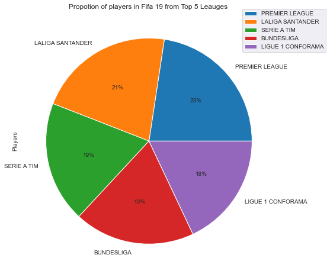

```python
league_count = data['League'].value_counts()
league_count = league_count[1:6]


df1=pd.DataFrame(league_count)


df1.rename(columns={'League':'Players'},inplace=True)
df1['Leauge']=df1.index
display(df1)


plot = df1.plot.pie(y='Players', figsize=(8, 8),autopct='%1.0f%%')
plt.legend( bbox_to_anchor=(0.85,1.025), loc="upper left")
plt.title("Propotion of players in Fifa 19 from Top 5 Leauges ")
plt.show()

#fig = px.bar(df, x=df.League , y=df.Leauge_name, text=df.League,
 #            title="Propotion of players in Fifa 19 from Top 5 Leauges", barmode='group',
  #           color=df.League,  color_continuous_scale='Aggrnyl')
#fig.update_traces(texttemplate='%{text:.3s}', textposition='inside')
#fig.update_layout(uniformtext_minsize=6, uniformtext_mode='hide')
#fig.show()
```

```python
# Create a new DataFrame of top clubs with the best average overall ratings
top_clubs_overall = data.groupby("Club",as_index=False)["Overall"].sum().sort_values("Overall", ascending=False).head(10)
display(top_clubs_overall)


top_clubs_overall=top_clubs_overall.sort_values('Overall',ascending=True)
fig = px.bar(top_clubs_overall, x='Overall' , y='Club', text='Overall',
             title="Clubs with the best overall ratings", barmode='group',
             color='Overall',  color_continuous_scale='viridis')
fig.update_traces(texttemplate='%{text:.3s}', textposition='inside')
fig.update_layout(uniformtext_minsize=8, uniformtext_mode='hide')
fig.show()
```

|  | Club | Overall |
| --- | --- | --- |
| 470 | Real Madrid | 2582 |
| 212 | FC Barcelona | 2575 |
| 375 | Manchester United | 2549 |
| 134 | Chelsea | 2534 |
| 374 | Manchester City | 2532 |
| 583 | Tottenham Hotspur | 2531 |
| 363 | Liverpool | 2508 |
| 86 | Borussia Dortmund | 2486 |
| 52 | Arsenal | 2481 |
| 61 | Atlético Madrid | 2477 |

[interactive chart not shown]

### Plot for visualizing Fowards, Goalkeepers, Midfielders and Defender for Top 10 clubs

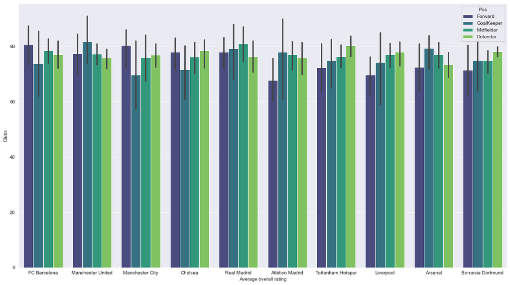

```python
#data[data['Club'] in top_clubs_overall['Club'].tolist()]
fig, ax = plt.subplots(figsize=[18,10])

top_clubs_overall=data[data['Club'].isin(top_clubs_overall['Club'].tolist())]
ax = sns.barplot(x=top_clubs_overall.Club, y=top_clubs_overall.Overall, hue=top_clubs_overall['Pos'],orient='v',palette='viridis')
#ax.legend('best')
plt.ylabel("Clubs")
plt.xlabel("Average overall rating");
```

## Best league in terms of clubs overall ranking

### Treemap for clustering Top clubs belonging to each league

```python
import plotly.express as px

fig = px.treemap(top_clubs_overall, path=[px.Constant('League'),'League','Club'],
                  color='League', hover_data=['Club','Overall'])
fig.show()
```

[interactive chart not shown]

## Best Defensive Club and most likely to concede fewest Goals

### Creating the dictionary for storing clubs as keys and its respectve players as values

```python
df_sliced_dict={}
for key in data['Club'].unique().tolist():
    df_sliced_dict[key]=data[data['Club']==key]
```

```python
#data['Weak Foot']
data.columns
```

```
Index(['Order', 'ID', 'Name', 'Age', 'Photo', 'Nationality', 'Flag', 'Overall',
       'Potential', 'Club', 'Club_Logo', 'Value', 'Wage', 'Special',
       'Preferred Foot', 'International Reputation', 'Weak Foot',
       'Skill Moves', 'Work Rate', 'Body Type', 'Real Face', 'Position',
       'Jersey Number', 'Joined', 'Loaned From', 'Contract Valid Until',
       'Height', 'Weight', 'LS', 'ST', 'RS', 'LW', 'LF', 'CF', 'RF', 'RW',
       'LAM', 'CAM', 'RAM', 'LM', 'LCM', 'CM', 'RCM', 'RM', 'LWB', 'LDM',
       'CDM', 'RDM', 'RWB', 'LB', 'LCB', 'CB', 'RCB', 'RB', 'Crossing',
       'Finishing', 'HeadingAccuracy', 'ShortPassing', 'Volleys', 'Dribbling',
       'Curve', 'FKAccuracy', 'LongPassing', 'BallControl', 'Acceleration',
       'SprintSpeed', 'Agility', 'Reactions', 'Balance', 'ShotPower',
       'Jumping', 'Stamina', 'Strength', 'LongShots', 'Aggression',
       'Interceptions', 'Positioning', 'Vision', 'Penalties', 'Composure',
       'Marking', 'StandingTackle', 'SlidingTackle', 'GKDiving', 'GKHandling',
       'GKKicking', 'GKPositioning', 'GKReflexes', 'Release Clause',
       'Defending', 'General', 'Mental', 'Passing', 'Mobility', 'Power',
       'Rating', 'Shooting', 'Pos', 'League'],
      dtype='object')
```

### Defensive Score for each club

In order to find the defensive score for each club, the players playing at defensive positions like **LWB, LDM, CDM, RDM, RWB, LB, LCB, CB, RCB, RB, GK** were selected. Afterwards, the most impotant skills required for defending like **Interceptions, Positioning, Marking, StandingTackle, SlidingTackle, GKDiving, GKHandling, GKKicking** are summed up and then the average of the skills is calculated. A list is created to store the calculated defensive score for each club.

```python
list1=[]
for club in df_sliced_dict.keys():
    fifa_club=df_sliced_dict[club][(df_sliced_dict[club]['Position']=='LWB')|(df_sliced_dict[club]['Position']=='LDM')|
                                  (df_sliced_dict[club]['Position']=='CDM')|(df_sliced_dict[club]['Position']=='RDM')|
                                  (df_sliced_dict[club]['Position']=='RWB')|(df_sliced_dict[club]['Position']=='LB')|
                                  (df_sliced_dict[club]['Position']=='LCB')|(df_sliced_dict[club]['Position']=='CB')|
                                  (df_sliced_dict[club]['Position']=='RCB')|(df_sliced_dict[club]['Position']=='RB')|
                                  (df_sliced_dict[club]['Position']=='GK')]

    Defend_Ranking=fifa_club[['Stamina','Reactions','Balance','ShortPassing','Interceptions', 'Positioning',
       'Marking', 'StandingTackle', 'SlidingTackle', 'GKDiving', 'GKHandling',
       'GKKicking', 'GKPositioning', 'GKReflexes','Jumping','Strength'
       ]].sum().mean()

    df_sliced_dict[club]['Defend_Ranking']=Defend_Ranking

    #display(df_sliced_dict[club][['Club','Defend_Ranking']])
    list1.append(df_sliced_dict[club][['Club','Defend_Ranking']].iloc[0])
```

### It is observed that Leicester City has the best defensive score among all the clubs in fifa 19 and hence will concede the fewest goals.

```python
Defend_Ranking=pd.DataFrame(list1)
Defend_Ranking=Defend_Ranking.sort_values('Defend_Ranking',ascending=False).head(10)
Defend_Ranking.rename(columns={'Defend_Ranking':'Defensive Score'},inplace=True)
Defend_Ranking.reset_index(drop=True,inplace=True)
display(Defend_Ranking)
```

|  | Club | Defensive Score |
| --- | --- | --- |
| 0 | Leicester City | 1013.2500 |
| 1 | Arsenal | 1002.2500 |
| 2 | Everton | 981.2500 |
| 3 | Manchester City | 976.4375 |
| 4 | Toulouse Football Club | 970.7500 |
| 5 | Çaykur Rizespor | 970.5000 |
| 6 | Olympique de Marseille | 943.7500 |
| 7 | AS Monaco | 940.9375 |
| 8 | Real Madrid | 937.0000 |
| 9 | FC Augsburg | 935.1250 |

### Horizontal Bar plot for visualizing the top defensive clubs

We can see from the graph that Leicester City is leading the race when in comes to defending followed by other english clubs like Arsenal, Everton and Manchester city.

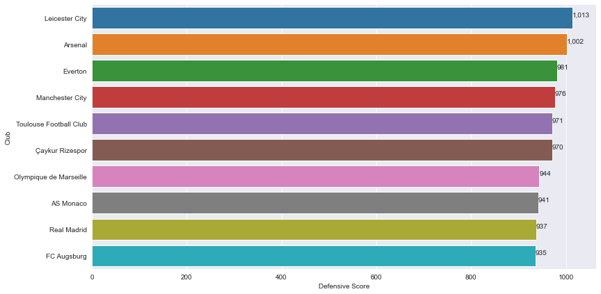

```python
plt.figure(figsize=(13,7))
x=Defend_Ranking['Defensive Score']
y=Defend_Ranking['Club']
plot = sns.barplot(x,y)
for i,(value,name) in enumerate(zip(x,y)):
    plot.text(value,i-0.05,f'{value:,.0f}',size=10)
plt.show()
```

## Club Analysis : Juventus vs FC Barcelona

### Numbers of players at playing positions in Juventus and Barcelona

Juventus has total of 25 players and among them, 9 plays as defender and midfielder while 4 at Forward position and 3 players at Goalkeeping position. On the other hand, FC Barcelona has total of 33 players and 11 plays as defender, 10 plays as defender, 8 as forwards and 4 at goalkeeping position

```python
list_loop=['Juventus','FC Barcelona']
for club in list_loop:
    display(club)
    display(df_sliced_dict[club][['Name','Pos']])
    display(df_sliced_dict[club]['Pos'].value_counts())
```

```
'Juventus'
```

|  | Name | Pos |
| --- | --- | --- |
| 1 | Cristiano Ronaldo | Forward |
| 15 | P. Dybala | Forward |
| 24 | G. Chiellini | Defender |
| 64 | Alex Sandro | Defender |
| 65 | Douglas Costa | Midfielder |
| 70 | L. Bonucci | Defender |
| 72 | M. Pjanić | Midfielder |
| 73 | M. Benatia | Defender |
| 92 | W. Szczęsny | GoalKeeper |
| 99 | S. Khedira | Midfielder |
| 103 | B. Matuidi | Midfielder |
| 128 | M. Perin | GoalKeeper |
| 129 | J. Cuadrado | Midfielder |
| 139 | M. Mandžukić | Forward |
| 152 | A. Barzagli | Defender |
| 243 | F. Bernardeschi | Midfielder |
| 245 | D. Rugani | Defender |
| 247 | João Cancelo | Defender |
| 448 | E. Can | Midfielder |
| 815 | M. De Sciglio | Defender |
| 1049 | L. Spinazzola | Midfielder |
| 1149 | R. Bentancur | Midfielder |
| 3418 | M. Kean | Forward |
| 3700 | C. Pinsoglio | GoalKeeper |
| 13896 | P. Beruatto | Defender |

```
Defender      9
Midfielder    9
Forward       4
GoalKeeper    3
Name: Pos, dtype: int64
```

```
'FC Barcelona'
```

|  | Name | Pos |
| --- | --- | --- |
| 0 | L. Messi | Forward |
| 7 | L. Suárez | Forward |
| 18 | M. ter Stegen | GoalKeeper |
| 20 | Sergio Busquets | Midfielder |
| 32 | Coutinho | Forward |
| 42 | S. Umtiti | Defender |
| 49 | Jordi Alba | Defender |
| 53 | I. Rakitić | Midfielder |
| 54 | Piqué | Defender |
| 96 | A. Vidal | Midfielder |
| 155 | O. Dembélé | Forward |
| 192 | Sergi Roberto | Defender |
| 228 | Arthur | Midfielder |
| 236 | Malcom | Forward |
| 239 | C. Lenglet | Defender |
| 263 | Rafinha | Midfielder |
| 266 | J. Cillessen | GoalKeeper |
| 324 | Nélson Semedo | Defender |
| 613 | Denis Suárez | Midfielder |
| 1007 | Munir | Forward |
| 1037 | T. Vermaelen | Defender |
| 3118 | Sergi Samper | Midfielder |
| 3684 | Aleñá | Midfielder |
| 6000 | M. Wagué | Defender |
| 6102 | Riqui Puig | Midfielder |
| 8284 | Oriol Busquets | Midfielder |
| 8289 | Abel Ruiz | Forward |
| 8857 | Miranda | Defender |
| 10526 | Chumi | Defender |
| 10777 | Jorge Cuenca | Defender |
| 11300 | Guillem Jaime | Forward |
| 12502 | Ezkieta | GoalKeeper |
| 14286 | Iñaki Peña | GoalKeeper |

```
Defender      11
Midfielder    10
Forward        8
GoalKeeper     4
Name: Pos, dtype: int64
```

### Best players per each position in Juventus and FC Barcelona based on their overall scores

The players are distinguished based on their position on Football. It is evident from the overall score that Cristiano Ronaldo is best among all the strikers in Juventus while Lionel Messi holds the highest position when it comes to forwards in FC Barcelona.

```python
data_Juventus=data[data['Club']=='Juventus']
data_Juventus.reset_index(drop=True,inplace=True)
#display(data_Juventus)
display(data_Juventus.iloc[data_Juventus.groupby(data_Juventus['Pos'])['Overall'].idxmax()][['Pos', 'Name',
                                                               'Overall', 'Club', 'Nationality']].style.background_gradient('Greens'))

data_Juventus=data[data['Club']=='FC Barcelona']
data_Juventus.reset_index(drop=True,inplace=True)
#display(data_Juventus)
data_Juventus.iloc[data_Juventus.groupby(data_Juventus['Pos'])['Overall'].idxmax()][['Pos', 'Name',
                                                               'Overall', 'Club', 'Nationality']].style.background_gradient('Greens')
```

|  | Pos | Name | Overall | Club | Nationality |
| --- | --- | --- | --- | --- | --- |
| 2 | Defender | G. Chiellini | 89 | Juventus | Italy |
| 0 | Forward | Cristiano Ronaldo | 94 | Juventus | Portugal |
| 8 | GoalKeeper | W. Szczęsny | 85 | Juventus | Poland |
| 4 | Midfielder | Douglas Costa | 86 | Juventus | Brazil |

|  | Pos | Name | Overall | Club | Nationality |
| --- | --- | --- | --- | --- | --- |
| 5 | Defender | S. Umtiti | 87 | FC Barcelona | France |
| 0 | Forward | L. Messi | 94 | FC Barcelona | Argentina |
| 2 | GoalKeeper | M. ter Stegen | 89 | FC Barcelona | Germany |
| 3 | Midfielder | Sergio Busquets | 89 | FC Barcelona | Spain |

### Defensive Score for Juventus and FC Barcelona

In order to find the defensive score for Juventus and Barcelona, the players playing at defensive positions like **LWB, LDM, CDM, RDM, RWB, LB, LCB, CB, RCB, RB, GK** were selected. Afterwards, the most impotant skills required for defending like **Interceptions, Positioning, Marking, StandingTackle, SlidingTackle, GKDiving, GKHandling, GKKicking** are summed up and then the average of the skills is calculated. A list is created to store the calculated defensive score for each club.

```python
list_loop=['Juventus','FC Barcelona']
list1=[]
for club in list_loop:
    fifa_club=df_sliced_dict[club][(df_sliced_dict[club]['Position']=='LWB')|(df_sliced_dict[club]['Position']=='LDM')|
                                  (df_sliced_dict[club]['Position']=='CDM')|(df_sliced_dict[club]['Position']=='RDM')|
                                  (df_sliced_dict[club]['Position']=='RWB')|(df_sliced_dict[club]['Position']=='LB')|
                                  (df_sliced_dict[club]['Position']=='LCB')|(df_sliced_dict[club]['Position']=='CB')|
                                  (df_sliced_dict[club]['Position']=='RCB')|(df_sliced_dict[club]['Position']=='RB')|
                                  (df_sliced_dict[club]['Position']=='GK')]

    Defend_Ranking=fifa_club[['Stamina','Reactions','Balance','ShortPassing','Interceptions', 'Positioning',
       'Marking', 'StandingTackle', 'SlidingTackle', 'GKDiving', 'GKHandling',
       'GKKicking', 'GKPositioning', 'GKReflexes','Jumping','Strength'
       ]].sum().mean()

    df_sliced_dict[club]['Defend_Ranking']=Defend_Ranking

    #display(df_sliced_dict[club][['Club','Defend_Ranking']])
    list1.append(df_sliced_dict[club][['Club','Defend_Ranking']].iloc[0])
```

```python
Defend_Ranking=pd.DataFrame(list1)
Defend_Ranking=Defend_Ranking.sort_values('Defend_Ranking',ascending=False).head(10)
Defend_Ranking.rename(columns={'Defend_Ranking':'Defensive Score'},inplace=True)
Defend_Ranking.reset_index(drop=True,inplace=True)
display(Defend_Ranking)
```

|  | Club | Defensive Score |
| --- | --- | --- |
| 0 | FC Barcelona | 922.9375 |
| 1 | Juventus | 675.0000 |

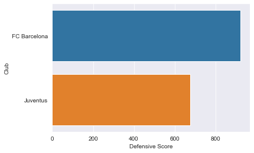

```python
plt.figure(figsize=(13,7))

fig, ax = plt.subplots()
x=Defend_Ranking['Defensive Score']
y=Defend_Ranking['Club']
ax = sns.barplot(x,y)
for i,(value,name) in enumerate(zip(x,y)):
    plot.text(value,i-0.05,f'{value:,.0f}',size=10)
plt.show()
```

### Attacking Score for each club

```python
list_loop=['Juventus','FC Barcelona']
list1=[]
for club in list_loop:
    fifa_club=df_sliced_dict[club][(df_sliced_dict[club]['Position']=='LS')|(df_sliced_dict[club]['Position']=='ST')|
                                  (df_sliced_dict[club]['Position']=='RS')|(df_sliced_dict[club]['Position']=='LW')|
                                  (df_sliced_dict[club]['Position']=='LF')|(df_sliced_dict[club]['Position']=='CF')|
                                  (df_sliced_dict[club]['Position']=='RF')|(df_sliced_dict[club]['Position']=='RW')|
                                  (df_sliced_dict[club]['Position']=='LAM')|(df_sliced_dict[club]['Position']=='CAM')|
                                  (df_sliced_dict[club]['Position']=='RAM')|(df_sliced_dict[club]['Position']=='LM')|
                                  (df_sliced_dict[club]['Position']=='LCM')|(df_sliced_dict[club]['Position']=='CM')|
                                  (df_sliced_dict[club]['Position']=='RCM')|(df_sliced_dict[club]['Position']=='RM')]

    Attack_Ranking=fifa_club[['Crossing',
       'Finishing', 'HeadingAccuracy', 'ShortPassing', 'Dribbling',
       'Curve', 'FKAccuracy', 'LongPassing', 'BallControl', 'Acceleration',
       'SprintSpeed', 'Agility', 'Reactions', 'Balance', 'ShotPower',
       'Jumping', 'Stamina', 'Strength', 'LongShots','Aggression','Vision','Penalties','Composure']].sum().mean()

    df_sliced_dict[club]['Attack_Ranking']=Attack_Ranking

    #display(df_sliced_dict[club][['Club','Attack_Ranking']])
    list1.append(df_sliced_dict[club][['Club','Attack_Ranking']].iloc[0])
```

#### FC Barcelona also fares better than Juventus when it comes to attacking score

```python
Attack_Ranking=pd.DataFrame(list1)
Attack_Ranking=Attack_Ranking.sort_values('Attack_Ranking',ascending=False).head(10)
Attack_Ranking.rename(columns={'Attack_Ranking':'Attacking score'},inplace=True)
Attack_Ranking
```

|  | Club | Attacking score |
| --- | --- | --- |
| 0 | FC Barcelona | 1095.739130 |
| 1 | Juventus | 901.347826 |

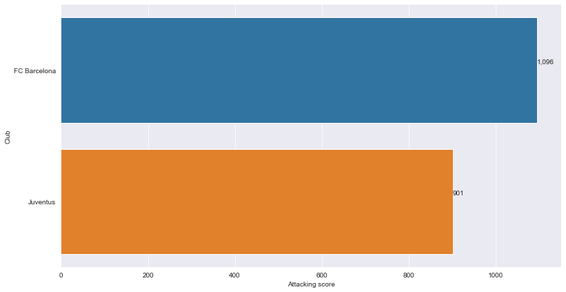

```python
#ax=sns.barplot(x='Club',y='Attacking score',data=Attack_Ranking)
#ax=Attack_Ranking.plot(x='Club',y='Attacking score',kind='bar')

plt.figure(figsize=(13,7))
x=Attack_Ranking['Attacking score']
y=Attack_Ranking['Club']
plot = sns.barplot(x,y)
for i,(value,name) in enumerate(zip(x,y)):
    plot.text(value,i-0.05,f'{value:,.0f}',size=10)
plt.show()
```

## Identifying Clusters Among Strikers

```python
new_df = pd.read_excel('2021-06-23_Dataset_Fifa_19.xlsx')
```

```python
new_df
```

|  | Order | ID | Name | Age | Photo | Nationality | Flag | Overall | Potential | Club | ... | Composure | Marking | StandingTackle | SlidingTackle | GKDiving | GKHandling | GKKicking | GKPositioning | GKReflexes | Release Clause |
| --- | --- | --- | --- | --- | --- | --- | --- | --- | --- | --- | --- | --- | --- | --- | --- | --- | --- | --- | --- | --- | --- |
| 0 | 0 | 158023 | L. Messi | 31 | https://cdn.sofifa.org/players/4/19/158023.png | Argentina | https://cdn.sofifa.org/flags/52.png | 94 | 94 | FC Barcelona | ... | 96.0 | 33.0 | 28.0 | 26.0 | 6.0 | 11.0 | 15.0 | 14.0 | 8.0 | €226.5M |
| 1 | 1 | 20801 | Cristiano Ronaldo | 33 | https://cdn.sofifa.org/players/4/19/20801.png | Portugal | https://cdn.sofifa.org/flags/38.png | 94 | 94 | Juventus | ... | 95.0 | 28.0 | 31.0 | 23.0 | 7.0 | 11.0 | 15.0 | 14.0 | 11.0 | €127.1M |
| 2 | 2 | 190871 | Neymar Jr | 26 | https://cdn.sofifa.org/players/4/19/190871.png | Brazil | https://cdn.sofifa.org/flags/54.png | 92 | 93 | Paris Saint-Germain | ... | 94.0 | 27.0 | 24.0 | 33.0 | 9.0 | 9.0 | 15.0 | 15.0 | 11.0 | €228.1M |
| 3 | 3 | 193080 | De Gea | 27 | https://cdn.sofifa.org/players/4/19/193080.png | Spain | https://cdn.sofifa.org/flags/45.png | 91 | 93 | Manchester United | ... | 68.0 | 15.0 | 21.0 | 13.0 | 90.0 | 85.0 | 87.0 | 88.0 | 94.0 | €138.6M |
| 4 | 4 | 192985 | K. De Bruyne | 27 | https://cdn.sofifa.org/players/4/19/192985.png | Belgium | https://cdn.sofifa.org/flags/7.png | 91 | 92 | Manchester City | ... | 88.0 | 68.0 | 58.0 | 51.0 | 15.0 | 13.0 | 5.0 | 10.0 | 13.0 | €196.4M |
| ... | ... | ... | ... | ... | ... | ... | ... | ... | ... | ... | ... | ... | ... | ... | ... | ... | ... | ... | ... | ... | ... |
| 18202 | 18202 | 238813 | J. Lundstram | 19 | https://cdn.sofifa.org/players/4/19/238813.png | England | https://cdn.sofifa.org/flags/14.png | 47 | 65 | Crewe Alexandra | ... | 45.0 | 40.0 | 48.0 | 47.0 | 10.0 | 13.0 | 7.0 | 8.0 | 9.0 | €143K |
| 18203 | 18203 | 243165 | N. Christoffersson | 19 | https://cdn.sofifa.org/players/4/19/243165.png | Sweden | https://cdn.sofifa.org/flags/46.png | 47 | 63 | Trelleborgs FF | ... | 42.0 | 22.0 | 15.0 | 19.0 | 10.0 | 9.0 | 9.0 | 5.0 | 12.0 | €113K |
| 18204 | 18204 | 241638 | B. Worman | 16 | https://cdn.sofifa.org/players/4/19/241638.png | England | https://cdn.sofifa.org/flags/14.png | 47 | 67 | Cambridge United | ... | 41.0 | 32.0 | 13.0 | 11.0 | 6.0 | 5.0 | 10.0 | 6.0 | 13.0 | €165K |
| 18205 | 18205 | 246268 | D. Walker-Rice | 17 | https://cdn.sofifa.org/players/4/19/246268.png | England | https://cdn.sofifa.org/flags/14.png | 47 | 66 | Tranmere Rovers | ... | 46.0 | 20.0 | 25.0 | 27.0 | 14.0 | 6.0 | 14.0 | 8.0 | 9.0 | €143K |
| 18206 | 18206 | 246269 | G. Nugent | 16 | https://cdn.sofifa.org/players/4/19/246269.png | England | https://cdn.sofifa.org/flags/14.png | 46 | 66 | Tranmere Rovers | ... | 43.0 | 40.0 | 43.0 | 50.0 | 10.0 | 15.0 | 9.0 | 12.0 | 9.0 | €165K |

18207 rows × 89 columns

#### Now,after reading the data we have to remove the columns which are of less priority or unwanted.Below we are removing the unwanted columns for our analysis:

[output not shown]

```python
#listing the columns to be dropped

list_remove_columns = ['Photo', 'Nationality', 'Flag', 'Potential','Club Logo', 'Wage', 'Special', 'International Reputation',
                      'Skill Moves', 'Work Rate', 'Body Type', 'Real Face','Jersey Number', 'Joined', 'Loaned From', 'Contract Valid Until','Release Clause']
```

#### After the columns are dropped the resulting dataframe is stored in a new dataframe named "data"

```python
Data = new_df.drop(list_remove_columns,axis=1)
```

## PreProcessing Data for Clustering

### After the required columns are selected, the next step in Data Analysis is Preprocessing the data.

```
* As part of Preprocessing ,here we are filling all thr missing values with '0' initially.
* Then the entire data is seperated into two subsets based on the column 'Weight'. df_1 represents rows with Weight              value not equal zero and df_2 contains rows with Weight value '0'.
* The 'Weight' attribute in the given dataset is in the form of a string eg : "180lbs" , so for performing analysis,the          unwanted "lbs" part is trimmed and only numerical data is stroed int the Weight Column.
* Next, the 'Height' attribute in the dataset is given as a string eg: "5'7",below we are converting the height into              centimeters and storing in the height column.
* Once the required columns have been modified , the two data_frames df_1 and df_2 are combimed together and all the              values which have been filled with 0 are now filled with mean of the values.
```

```python
#here we are filling NAN values with '0' for further analysis.Going forward we replace the 0 values with actual
#means of particular cloumn

new_data = Data.fillna(0)
```

```python
#removing 'lbs' from the weight values and taking only the numerical part
df_1 = new_data[new_data['Weight']!=0]
df_2 = new_data[new_data['Weight']==0]

#data['Weight']= data['Weight'].map(lambda x: x.rstrip('lbs'))
```

```python
#displaying the dataframe df_1 for understanding the data in it

df_1
```

|  | Order | ID | Name | Age | Overall | Club | Value | Preferred Foot | Weak Foot | Position | ... | Penalties | Composure | Marking | StandingTackle | SlidingTackle | GKDiving | GKHandling | GKKicking | GKPositioning | GKReflexes |
| --- | --- | --- | --- | --- | --- | --- | --- | --- | --- | --- | --- | --- | --- | --- | --- | --- | --- | --- | --- | --- | --- |
| 0 | 0 | 158023 | L. Messi | 31 | 94 | FC Barcelona | €110.5M | Left | 4.0 | RF | ... | 75.0 | 96.0 | 33.0 | 28.0 | 26.0 | 6.0 | 11.0 | 15.0 | 14.0 | 8.0 |
| 1 | 1 | 20801 | Cristiano Ronaldo | 33 | 94 | Juventus | €77M | Right | 4.0 | ST | ... | 85.0 | 95.0 | 28.0 | 31.0 | 23.0 | 7.0 | 11.0 | 15.0 | 14.0 | 11.0 |
| 2 | 2 | 190871 | Neymar Jr | 26 | 92 | Paris Saint-Germain | €118.5M | Right | 5.0 | LW | ... | 81.0 | 94.0 | 27.0 | 24.0 | 33.0 | 9.0 | 9.0 | 15.0 | 15.0 | 11.0 |
| 3 | 3 | 193080 | De Gea | 27 | 91 | Manchester United | €72M | Right | 3.0 | GK | ... | 40.0 | 68.0 | 15.0 | 21.0 | 13.0 | 90.0 | 85.0 | 87.0 | 88.0 | 94.0 |
| 4 | 4 | 192985 | K. De Bruyne | 27 | 91 | Manchester City | €102M | Right | 5.0 | RCM | ... | 79.0 | 88.0 | 68.0 | 58.0 | 51.0 | 15.0 | 13.0 | 5.0 | 10.0 | 13.0 |
| ... | ... | ... | ... | ... | ... | ... | ... | ... | ... | ... | ... | ... | ... | ... | ... | ... | ... | ... | ... | ... | ... |
| 18202 | 18202 | 238813 | J. Lundstram | 19 | 47 | Crewe Alexandra | €60K | Right | 2.0 | CM | ... | 43.0 | 45.0 | 40.0 | 48.0 | 47.0 | 10.0 | 13.0 | 7.0 | 8.0 | 9.0 |
| 18203 | 18203 | 243165 | N. Christoffersson | 19 | 47 | Trelleborgs FF | €60K | Right | 2.0 | ST | ... | 43.0 | 42.0 | 22.0 | 15.0 | 19.0 | 10.0 | 9.0 | 9.0 | 5.0 | 12.0 |
| 18204 | 18204 | 241638 | B. Worman | 16 | 47 | Cambridge United | €60K | Right | 3.0 | ST | ... | 55.0 | 41.0 | 32.0 | 13.0 | 11.0 | 6.0 | 5.0 | 10.0 | 6.0 | 13.0 |
| 18205 | 18205 | 246268 | D. Walker-Rice | 17 | 47 | Tranmere Rovers | €60K | Right | 3.0 | RW | ... | 50.0 | 46.0 | 20.0 | 25.0 | 27.0 | 14.0 | 6.0 | 14.0 | 8.0 | 9.0 |
| 18206 | 18206 | 246269 | G. Nugent | 16 | 46 | Tranmere Rovers | €60K | Right | 3.0 | CM | ... | 33.0 | 43.0 | 40.0 | 43.0 | 50.0 | 10.0 | 15.0 | 9.0 | 12.0 | 9.0 |

18131 rows × 72 columns

```python
#displaying the dataframe df_2 for understanding the data in it

df_2
```

|  | Order | ID | Name | Age | Overall | Club | Value | Preferred Foot | Weak Foot | Position | ... | Penalties | Composure | Marking | StandingTackle | SlidingTackle | GKDiving | GKHandling | GKKicking | GKPositioning | GKReflexes |
| --- | --- | --- | --- | --- | --- | --- | --- | --- | --- | --- | --- | --- | --- | --- | --- | --- | --- | --- | --- | --- | --- |
| 461 | 461 | 204399 | E. Zahavi | 30 | 80 | Guangzhou R&F | 0 | 0 | 0.0 | 0 | ... | 0.0 | 0.0 | 0.0 | 0.0 | 0.0 | 0.0 | 0.0 | 0.0 | 0.0 | 0.0 |
| 1758 | 1758 | 206171 | Júnior Urso | 29 | 75 | Guangzhou R&F | 0 | 0 | 0.0 | 0 | ... | 0.0 | 0.0 | 0.0 | 0.0 | 0.0 | 0.0 | 0.0 | 0.0 | 0.0 | 0.0 |
| 2262 | 2262 | 192349 | Renatinho | 29 | 74 | Guangzhou R&F | 0 | 0 | 0.0 | 0 | ... | 0.0 | 0.0 | 0.0 | 0.0 | 0.0 | 0.0 | 0.0 | 0.0 | 0.0 | 0.0 |
| 2590 | 2590 | 176377 | D. Tošić | 33 | 74 | Guangzhou R&F | 0 | 0 | 0.0 | 0 | ... | 0.0 | 0.0 | 0.0 | 0.0 | 0.0 | 0.0 | 0.0 | 0.0 | 0.0 | 0.0 |
| 5881 | 5881 | 222278 | Tang Miao | 27 | 69 | Guangzhou R&F | 0 | 0 | 0.0 | 0 | ... | 0.0 | 0.0 | 0.0 | 0.0 | 0.0 | 0.0 | 0.0 | 0.0 | 0.0 | 0.0 |
| ... | ... | ... | ... | ... | ... | ... | ... | ... | ... | ... | ... | ... | ... | ... | ... | ... | ... | ... | ... | ... | ... |
| 17964 | 17964 | 242847 | Cai Haojian | 22 | 51 | Guangzhou R&F | 0 | 0 | 0.0 | 0 | ... | 0.0 | 0.0 | 0.0 | 0.0 | 0.0 | 0.0 | 0.0 | 0.0 | 0.0 | 0.0 |
| 18067 | 18067 | 241303 | Zhang Gong | 26 | 50 | Guangzhou R&F | 0 | 0 | 0.0 | 0 | ... | 0.0 | 0.0 | 0.0 | 0.0 | 0.0 | 0.0 | 0.0 | 0.0 | 0.0 | 0.0 |
| 18141 | 18141 | 242849 | Chen Yajun | 19 | 49 | Guangzhou R&F | 0 | 0 | 0.0 | 0 | ... | 0.0 | 0.0 | 0.0 | 0.0 | 0.0 | 0.0 | 0.0 | 0.0 | 0.0 | 0.0 |
| 18142 | 18142 | 233395 | Li Yuyang | 20 | 49 | Guangzhou R&F | 0 | 0 | 0.0 | 0 | ... | 0.0 | 0.0 | 0.0 | 0.0 | 0.0 | 0.0 | 0.0 | 0.0 | 0.0 | 0.0 |
| 18163 | 18163 | 242852 | Wang Xin | 20 | 48 | Guangzhou R&F | 0 | 0 | 0.0 | 0 | ... | 0.0 | 0.0 | 0.0 | 0.0 | 0.0 | 0.0 | 0.0 | 0.0 | 0.0 | 0.0 |

76 rows × 72 columns

#### The 'lbs' part of weight values are trimmed and numerical values are stored back into the Weight column.

```python
#removing the lbs part from Weight values using rstrip() function of string

df_1['Weight']= df_1['Weight'].map(lambda x: x.rstrip('lbs'))
```

```python
#verifying the data after performing the changes
#as shown below the 'lbs' part of weight has been removed

df_1['Weight']
```

```
0        159
1        183
2        150
3        168
4        154
        ...
18202    134
18203    170
18204    148
18205    154
18206    176
Name: Weight, Length: 18131, dtype: object
```

#### For converting the height into format comaptible for analysis,we are changing the given height into centimeters using regular expressions.The value before ' is taken into group(1) and value after it is taken into group(2).

```
Then the height in centimeters is calculated using the formula (int(m.group(1))*12 + float(m.group(2)))*2.54
```

```python
#converting the given height into inches


r = re.compile(r"([0-9]+)'([0-9]*)")
def get_height(height):
    m = r.match(height)
    if m == None:
        return float('NaN')
    else:
        return (int(m.group(1))*12 + float(m.group(2)))*2.54
df_1['Height'] = df_1["Height"].apply(lambda x:get_height(x))
```

```python
df_1
```

|  | Order | ID | Name | Age | Overall | Club | Value | Preferred Foot | Weak Foot | Position | ... | Penalties | Composure | Marking | StandingTackle | SlidingTackle | GKDiving | GKHandling | GKKicking | GKPositioning | GKReflexes |
| --- | --- | --- | --- | --- | --- | --- | --- | --- | --- | --- | --- | --- | --- | --- | --- | --- | --- | --- | --- | --- | --- |
| 0 | 0 | 158023 | L. Messi | 31 | 94 | FC Barcelona | €110.5M | Left | 4.0 | RF | ... | 75.0 | 96.0 | 33.0 | 28.0 | 26.0 | 6.0 | 11.0 | 15.0 | 14.0 | 8.0 |
| 1 | 1 | 20801 | Cristiano Ronaldo | 33 | 94 | Juventus | €77M | Right | 4.0 | ST | ... | 85.0 | 95.0 | 28.0 | 31.0 | 23.0 | 7.0 | 11.0 | 15.0 | 14.0 | 11.0 |
| 2 | 2 | 190871 | Neymar Jr | 26 | 92 | Paris Saint-Germain | €118.5M | Right | 5.0 | LW | ... | 81.0 | 94.0 | 27.0 | 24.0 | 33.0 | 9.0 | 9.0 | 15.0 | 15.0 | 11.0 |
| 3 | 3 | 193080 | De Gea | 27 | 91 | Manchester United | €72M | Right | 3.0 | GK | ... | 40.0 | 68.0 | 15.0 | 21.0 | 13.0 | 90.0 | 85.0 | 87.0 | 88.0 | 94.0 |
| 4 | 4 | 192985 | K. De Bruyne | 27 | 91 | Manchester City | €102M | Right | 5.0 | RCM | ... | 79.0 | 88.0 | 68.0 | 58.0 | 51.0 | 15.0 | 13.0 | 5.0 | 10.0 | 13.0 |
| ... | ... | ... | ... | ... | ... | ... | ... | ... | ... | ... | ... | ... | ... | ... | ... | ... | ... | ... | ... | ... | ... |
| 18202 | 18202 | 238813 | J. Lundstram | 19 | 47 | Crewe Alexandra | €60K | Right | 2.0 | CM | ... | 43.0 | 45.0 | 40.0 | 48.0 | 47.0 | 10.0 | 13.0 | 7.0 | 8.0 | 9.0 |
| 18203 | 18203 | 243165 | N. Christoffersson | 19 | 47 | Trelleborgs FF | €60K | Right | 2.0 | ST | ... | 43.0 | 42.0 | 22.0 | 15.0 | 19.0 | 10.0 | 9.0 | 9.0 | 5.0 | 12.0 |
| 18204 | 18204 | 241638 | B. Worman | 16 | 47 | Cambridge United | €60K | Right | 3.0 | ST | ... | 55.0 | 41.0 | 32.0 | 13.0 | 11.0 | 6.0 | 5.0 | 10.0 | 6.0 | 13.0 |
| 18205 | 18205 | 246268 | D. Walker-Rice | 17 | 47 | Tranmere Rovers | €60K | Right | 3.0 | RW | ... | 50.0 | 46.0 | 20.0 | 25.0 | 27.0 | 14.0 | 6.0 | 14.0 | 8.0 | 9.0 |
| 18206 | 18206 | 246269 | G. Nugent | 16 | 46 | Tranmere Rovers | €60K | Right | 3.0 | CM | ... | 33.0 | 43.0 | 40.0 | 43.0 | 50.0 | 10.0 | 15.0 | 9.0 | 12.0 | 9.0 |

18131 rows × 72 columns

```
Here the two dataframes df_1 and df_2 are combined and stored in a new datafram "Final_data" , which will be used in further alaysis.
```

```python
#appending the two dataframes into one for performing further analysis

Final_data = df_1.append(df_2)
```

```python
#converting the datatype of Height and weight to integer to calculate the mean and fill null values

Final_data['Weight']=Final_data['Weight'].astype(int)
Final_data['Height']=Final_data['Height'].astype(int)
```

```python
Final_data.info()
```

```
<class 'pandas.core.frame.DataFrame'>
Int64Index: 18207 entries, 0 to 18163
Data columns (total 72 columns):
 #   Column           Non-Null Count  Dtype
---  ------           --------------  -----
 0   Order            18207 non-null  int64
 1   ID               18207 non-null  int64
 2   Name             18207 non-null  object
 3   Age              18207 non-null  int64
 4   Overall          18207 non-null  int64
 5   Club             18207 non-null  object
 6   Value            18207 non-null  object
 7   Preferred Foot   18207 non-null  object
 8   Weak Foot        18207 non-null  float64
 9   Position         18207 non-null  object
```

[output cut: 64 more lines]

### Replacing 0 values with mean of columns

```
 Once the modifications to the columns have been made , the next step performed here is replacing the values previously          filled with '0' with the mean of respective column.
 As we will only be using the numerical columns in further analysis, we are replacing '0' values only in numerical              columns with mean.

 Examples : Weight,Height,Dribbling etc.
```

```python
#Here we are replacing the NAN values which have been previously filled with '0' , with mean of the column


Final_data['Weight'].replace(to_replace = 0, value = Final_data['Weight'].mean(),inplace = True)
Final_data['ShortPassing'].replace(to_replace = 0, value = Final_data['ShortPassing'].mean(),inplace = True)
Final_data['Volleys'].replace(to_replace = 0, value = Final_data['Volleys'].mean(),inplace = True)
Final_data['Dribbling'].replace(to_replace = 0, value = Final_data['Dribbling'].mean(),inplace = True)
Final_data['Curve'].replace(to_replace = 0, value = Final_data['Curve'].mean(),inplace = True)
Final_data['FKAccuracy'].replace(to_replace = 0, value = Final_data['FKAccuracy'].mean(),inplace = True)
Final_data['LongPassing'].replace(to_replace = 0, value = Final_data['LongPassing'].mean(),inplace = True)
Final_data['BallControl'].replace(to_replace = 0, value = Final_data['BallControl'].mean(),inplace = True)
Final_data['HeadingAccuracy'].replace(to_replace = 0, value = Final_data['HeadingAccuracy'].mean(),inplace = True)
Final_data['Finishing'].replace(to_replace = 0, value = Final_data['Finishing'].mean(),inplace = True)
Final_data['Crossing'].replace(to_replace = 0, value = Final_data['Crossing'].mean(),inplace = True)
Final_data['Height'].replace(to_replace = 0, value = Final_data['Height'].mean(),inplace = True)
#Final_data['Club'].replace(to_replace = 0, value = Final_data['Club'].mean(),inplace = True)
#Final_data['Weak Foot'].replace(to_replace = 0, value = Final_data['Weak Foot'].mean(),inplace = True)
#Final_data['Preferred Foot'].replace(to_replace = 0, value = Final_data['Preferred Foot'].mean(),inplace = True)
```

```python
def actual_rating(val):
    if type(val) == str:
        s1 = val[0:2]
        #s2 = val[-1]
        val = int(s1)
        return val

    else:
        return val
Final_data['ST_Score'] = Final_data["ST"].apply(lambda x:actual_rating(x))
```

```python
Final_data['ST_Score']
```

```
0        88
1        91
2        84
3         0
4        82
         ..
17964     0
18067     0
18141     0
18142     0
18163     0
Name: ST_Score, Length: 18207, dtype: int64
```

After the values have been replaced with their corresponding columns mean , the next step is filtering the players data whose position is 'ST' i.e Strikers for performing the Cluster analysis. The filtered Strikers data is stored in a new dataframe "Strikers_data".

```python
Strikers_data =Final_data[Final_data['Position']=='ST']
```

```python
Strikers_data
```

|  | Order | ID | Name | Age | Overall | Club | Value | Preferred Foot | Weak Foot | Position | ... | Composure | Marking | StandingTackle | SlidingTackle | GKDiving | GKHandling | GKKicking | GKPositioning | GKReflexes | ST_Score |
| --- | --- | --- | --- | --- | --- | --- | --- | --- | --- | --- | --- | --- | --- | --- | --- | --- | --- | --- | --- | --- | --- |
| 1 | 1 | 20801 | Cristiano Ronaldo | 33 | 94 | Juventus | €77M | Right | 4.0 | ST | ... | 95.0 | 28.0 | 31.0 | 23.0 | 7.0 | 11.0 | 15.0 | 14.0 | 11.0 | 91 |
| 10 | 10 | 188545 | R. Lewandowski | 29 | 90 | FC Bayern München | €77M | Right | 4.0 | ST | ... | 86.0 | 34.0 | 42.0 | 19.0 | 15.0 | 6.0 | 12.0 | 8.0 | 10.0 | 87 |
| 16 | 16 | 202126 | H. Kane | 24 | 89 | Tottenham Hotspur | €83.5M | Right | 4.0 | ST | ... | 89.0 | 56.0 | 36.0 | 38.0 | 8.0 | 10.0 | 11.0 | 14.0 | 11.0 | 86 |
| 23 | 23 | 153079 | S. Agüero | 30 | 89 | Manchester City | €64.5M | Right | 4.0 | ST | ... | 90.0 | 30.0 | 20.0 | 12.0 | 13.0 | 15.0 | 6.0 | 11.0 | 14.0 | 86 |
| 36 | 36 | 173731 | G. Bale | 28 | 88 | Real Madrid | €60M | Left | 3.0 | ST | ... | 86.0 | 54.0 | 55.0 | 52.0 | 15.0 | 15.0 | 11.0 | 5.0 | 6.0 | 86 |
| ... | ... | ... | ... | ... | ... | ... | ... | ... | ... | ... | ... | ... | ... | ... | ... | ... | ... | ... | ... | ... | ... |
| 18177 | 18177 | 238550 | R. Roache | 18 | 48 | Blackpool | €70K | Right | 3.0 | ST | ... | 49.0 | 18.0 | 16.0 | 11.0 | 6.0 | 9.0 | 11.0 | 7.0 | 12.0 | 47 |
| 18189 | 18189 | 240160 | A. Kaltner | 18 | 47 | SpVgg Unterhaching | €60K | Right | 3.0 | ST | ... | 37.0 | 28.0 | 15.0 | 22.0 | 15.0 | 5.0 | 14.0 | 12.0 | 8.0 | 45 |
| 18200 | 18200 | 231381 | J. Young | 18 | 47 | Swindon Town | €60K | Left | 2.0 | ST | ... | 50.0 | 15.0 | 17.0 | 14.0 | 11.0 | 15.0 | 12.0 | 12.0 | 11.0 | 45 |
| 18203 | 18203 | 243165 | N. Christoffersson | 19 | 47 | Trelleborgs FF | €60K | Right | 2.0 | ST | ... | 42.0 | 22.0 | 15.0 | 19.0 | 10.0 | 9.0 | 9.0 | 5.0 | 12.0 | 45 |
| 18204 | 18204 | 241638 | B. Worman | 16 | 47 | Cambridge United | €60K | Right | 3.0 | ST | ... | 41.0 | 32.0 | 13.0 | 11.0 | 6.0 | 5.0 | 10.0 | 6.0 | 13.0 | 45 |

2151 rows × 73 columns

## Clustering of Strikers

```
For performing the cluster analysis, the initial and important step is finding the features which will be helpful in finding the clusters.Here we have choosen features like "Height" , "Weight" , "Stamina" , "Strength".These featues are stored into a list "feature_list_1 " and the filtered data is stored in a new Dataframe "Strikers_data_for_clustering" .
```

```python
#features_list = ['Height','Weight','Stamina','Vision','Strength','Aggression','SprintSpeed','Jumping','Acceleration']

features_list_1 = ['Height','Weight','Stamina','Strength','ST_Score']
```

```python
#filtering the required features for clustering the strikers

Strikers_data_for_clustering = Strikers_data[features_list_1]
```

```python
#displaying the filtered data

Strikers_data_for_clustering
```

|  | Height | Weight | Stamina | Strength | ST_Score |
| --- | --- | --- | --- | --- | --- |
| 1 | 187.0 | 183.0 | 88.0 | 79.0 | 91 |
| 10 | 182.0 | 176.0 | 78.0 | 84.0 | 87 |
| 16 | 187.0 | 196.0 | 89.0 | 84.0 | 86 |
| 23 | 172.0 | 154.0 | 76.0 | 73.0 | 86 |
| 36 | 185.0 | 181.0 | 75.0 | 80.0 | 86 |
| ... | ... | ... | ... | ... | ... |
| 18177 | 177.0 | 163.0 | 51.0 | 44.0 | 47 |
| 18189 | 177.0 | 165.0 | 55.0 | 60.0 | 45 |
| 18200 | 175.0 | 157.0 | 31.0 | 31.0 | 45 |
| 18203 | 190.0 | 170.0 | 43.0 | 67.0 | 45 |
| 18204 | 172.0 | 148.0 | 55.0 | 32.0 | 45 |

2151 rows × 5 columns

```python
#clustering

silhouette_scores = []
for k in range(2, 11):
    kmeans = KMeans(n_clusters=k,init='k-means++')
    kmeans.fit(Strikers_data_for_clustering)
    score = silhouette_score(Strikers_data_for_clustering, kmeans.labels_)
    silhouette_scores.append(score)
```

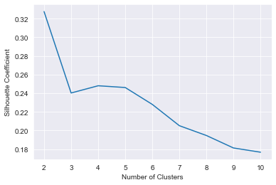

```python
plt.plot(range(2, 11), silhouette_scores)
plt.xticks(range(2, 11))
plt.xlabel("Number of Clusters")
plt.ylabel("Silhouette Coefficient")
plt.show()
```

```python
kmeans = KMeans(n_clusters=3,init='k-means++',random_state=3425)
```

```python
kmeans.fit(Strikers_data_for_clustering)
```

```
KMeans(algorithm='auto', copy_x=True, init='k-means++', max_iter=300,
       n_clusters=3, n_init=10, n_jobs=None, precompute_distances='auto',
       random_state=3425, tol=0.0001, verbose=0)
```

```python
Strikers_data['cluster_label']=kmeans.labels_
```

```python
cluster_0 = Strikers_data[Strikers_data['cluster_label']==0]
cluster_0
```

|  | Order | ID | Name | Age | Overall | Club | Value | Preferred Foot | Weak Foot | Position | ... | Marking | StandingTackle | SlidingTackle | GKDiving | GKHandling | GKKicking | GKPositioning | GKReflexes | ST_Score | cluster_label |
| --- | --- | --- | --- | --- | --- | --- | --- | --- | --- | --- | --- | --- | --- | --- | --- | --- | --- | --- | --- | --- | --- |
| 1 | 1 | 20801 | Cristiano Ronaldo | 33 | 94 | Juventus | €77M | Right | 4.0 | ST | ... | 28.0 | 31.0 | 23.0 | 7.0 | 11.0 | 15.0 | 14.0 | 11.0 | 91 | 0 |
| 10 | 10 | 188545 | R. Lewandowski | 29 | 90 | FC Bayern München | €77M | Right | 4.0 | ST | ... | 34.0 | 42.0 | 19.0 | 15.0 | 6.0 | 12.0 | 8.0 | 10.0 | 87 | 0 |
| 16 | 16 | 202126 | H. Kane | 24 | 89 | Tottenham Hotspur | €83.5M | Right | 4.0 | ST | ... | 56.0 | 36.0 | 38.0 | 8.0 | 10.0 | 11.0 | 14.0 | 11.0 | 86 | 0 |
| 36 | 36 | 173731 | G. Bale | 28 | 88 | Real Madrid | €60M | Left | 3.0 | ST | ... | 54.0 | 55.0 | 52.0 | 15.0 | 15.0 | 11.0 | 5.0 | 6.0 | 86 | 0 |
| 47 | 47 | 192505 | R. Lukaku | 25 | 87 | Manchester United | €62.5M | Left | 3.0 | ST | ... | 30.0 | 30.0 | 30.0 | 8.0 | 15.0 | 14.0 | 7.0 | 10.0 | 84 | 0 |
| ... | ... | ... | ... | ... | ... | ... | ... | ... | ... | ... | ... | ... | ... | ... | ... | ... | ... | ... | ... | ... | ... |
| 17623 | 17623 | 240006 | T. Mannek | 21 | 53 | SC Paderborn 07 | €90K | Right | 3.0 | ST | ... | 23.0 | 30.0 | 24.0 | 12.0 | 9.0 | 14.0 | 6.0 | 13.0 | 52 | 0 |
| 17773 | 17773 | 230722 | S. Boyd | 20 | 52 | Shamrock Rovers | €110K | Right | 3.0 | ST | ... | 21.0 | 20.0 | 14.0 | 8.0 | 10.0 | 5.0 | 10.0 | 6.0 | 50 | 0 |
| 17810 | 17810 | 246151 | A. Ahl Holmström | 19 | 52 | Kalmar FF | €110K | Right | 3.0 | ST | ... | 18.0 | 18.0 | 14.0 | 8.0 | 9.0 | 11.0 | 12.0 | 8.0 | 51 | 0 |
| 17892 | 17892 | 242952 | S. Bareiro | 19 | 51 | CD Huachipato | €70K | Right | 3.0 | ST | ... | 17.0 | 18.0 | 19.0 | 13.0 | 6.0 | 6.0 | 10.0 | 7.0 | 50 | 0 |
| 18013 | 18013 | 243708 | W. Møller | 20 | 51 | Esbjerg fB | €70K | Right | 2.0 | ST | ... | 21.0 | 20.0 | 18.0 | 12.0 | 6.0 | 5.0 | 11.0 | 14.0 | 50 | 0 |

635 rows × 74 columns

```python
cluster_1 = Strikers_data[Strikers_data['cluster_label']==1]
cluster_1
```

|  | Order | ID | Name | Age | Overall | Club | Value | Preferred Foot | Weak Foot | Position | ... | Marking | StandingTackle | SlidingTackle | GKDiving | GKHandling | GKKicking | GKPositioning | GKReflexes | ST_Score | cluster_label |
| --- | --- | --- | --- | --- | --- | --- | --- | --- | --- | --- | --- | --- | --- | --- | --- | --- | --- | --- | --- | --- | --- |
| 23 | 23 | 153079 | S. Agüero | 30 | 89 | Manchester City | €64.5M | Right | 4.0 | ST | ... | 30.0 | 20.0 | 12.0 | 13.0 | 15.0 | 6.0 | 11.0 | 14.0 | 86 | 1 |
| 43 | 43 | 201399 | M. Icardi | 25 | 87 | Inter | €64.5M | Right | 4.0 | ST | ... | 45.0 | 24.0 | 20.0 | 13.0 | 9.0 | 5.0 | 7.0 | 9.0 | 84 | 1 |
| 87 | 87 | 193301 | A. Lacazette | 27 | 85 | Arsenal | €45M | Right | 4.0 | ST | ... | 29.0 | 42.0 | 30.0 | 11.0 | 6.0 | 9.0 | 5.0 | 6.0 | 82 | 1 |
| 124 | 124 | 202556 | M. Depay | 24 | 84 | Olympique Lyonnais | €42M | Right | 3.0 | ST | ... | 29.0 | 31.0 | 20.0 | 8.0 | 14.0 | 6.0 | 12.0 | 10.0 | 80 | 1 |
| 130 | 130 | 192629 | Iago Aspas | 30 | 84 | RC Celta | €30M | Left | 3.0 | ST | ... | 39.0 | 21.0 | 18.0 | 12.0 | 16.0 | 9.0 | 12.0 | 13.0 | 82 | 1 |
| ... | ... | ... | ... | ... | ... | ... | ... | ... | ... | ... | ... | ... | ... | ... | ... | ... | ... | ... | ... | ... | ... |
| 17992 | 17992 | 242907 | B. Reynolds | 17 | 51 | FC Dallas | €80K | Right | 2.0 | ST | ... | 16.0 | 22.0 | 21.0 | 14.0 | 13.0 | 9.0 | 7.0 | 13.0 | 50 | 1 |
| 17998 | 17998 | 240356 | T. Rohde | 18 | 51 | AC Horsens | €80K | Right | 3.0 | ST | ... | 21.0 | 18.0 | 18.0 | 15.0 | 10.0 | 12.0 | 13.0 | 6.0 | 49 | 1 |
| 18002 | 18002 | 244201 | L. Jephcott | 18 | 51 | Plymouth Argyle | €80K | Right | 3.0 | ST | ... | 19.0 | 16.0 | 11.0 | 9.0 | 6.0 | 10.0 | 15.0 | 8.0 | 50 | 1 |
| 18006 | 18006 | 241138 | A. Ammitzbøll | 19 | 51 | Aarhus GF | €70K | Right | 2.0 | ST | ... | 23.0 | 14.0 | 18.0 | 12.0 | 10.0 | 10.0 | 13.0 | 13.0 | 50 | 1 |
| 18203 | 18203 | 243165 | N. Christoffersson | 19 | 47 | Trelleborgs FF | €60K | Right | 2.0 | ST | ... | 22.0 | 15.0 | 19.0 | 10.0 | 9.0 | 9.0 | 5.0 | 12.0 | 45 | 1 |

1021 rows × 74 columns

```python
cluster_2 = Strikers_data[Strikers_data['cluster_label']==2]
cluster_2
```

|  | Order | ID | Name | Age | Overall | Club | Value | Preferred Foot | Weak Foot | Position | ... | Marking | StandingTackle | SlidingTackle | GKDiving | GKHandling | GKKicking | GKPositioning | GKReflexes | ST_Score | cluster_label |
| --- | --- | --- | --- | --- | --- | --- | --- | --- | --- | --- | --- | --- | --- | --- | --- | --- | --- | --- | --- | --- | --- |
| 695 | 695 | 178224 | J. Hernández | 30 | 79 | West Ham United | €12M | Right | 3.0 | ST | ... | 21.0 | 29.0 | 25.0 | 14.0 | 12.0 | 9.0 | 12.0 | 11.0 | 76 | 2 |
| 1027 | 1027 | 50542 | J. Defoe | 35 | 77 | Bournemouth | €4.1M | Right | 4.0 | ST | ... | 30.0 | 20.0 | 11.0 | 7.0 | 14.0 | 8.0 | 10.0 | 13.0 | 76 | 2 |
| 1137 | 1137 | 115909 | Rubén Castro | 37 | 77 | UD Las Palmas | €3.2M | Right | 3.0 | ST | ... | 36.0 | 12.0 | 14.0 | 14.0 | 8.0 | 15.0 | 8.0 | 12.0 | 76 | 2 |
| 1226 | 1226 | 213013 | F. Acheampong | 24 | 76 | Tianjin TEDA FC | €10.5M | Left | 3.0 | ST | ... | 42.0 | 62.0 | 52.0 | 14.0 | 9.0 | 10.0 | 16.0 | 13.0 | 75 | 2 |
| 1296 | 1296 | 234045 | H. Onyekuru | 21 | 76 | Galatasaray SK | €12.5M | Right | 4.0 | ST | ... | 37.0 | 38.0 | 25.0 | 12.0 | 9.0 | 9.0 | 6.0 | 11.0 | 72 | 2 |
| ... | ... | ... | ... | ... | ... | ... | ... | ... | ... | ... | ... | ... | ... | ... | ... | ... | ... | ... | ... | ... | ... |
| 18166 | 18166 | 243621 | N. Ayéva | 16 | 48 | Örebro SK | €70K | Right | 3.0 | ST | ... | 14.0 | 19.0 | 16.0 | 10.0 | 9.0 | 8.0 | 7.0 | 6.0 | 47 | 2 |
| 18177 | 18177 | 238550 | R. Roache | 18 | 48 | Blackpool | €70K | Right | 3.0 | ST | ... | 18.0 | 16.0 | 11.0 | 6.0 | 9.0 | 11.0 | 7.0 | 12.0 | 47 | 2 |
| 18189 | 18189 | 240160 | A. Kaltner | 18 | 47 | SpVgg Unterhaching | €60K | Right | 3.0 | ST | ... | 28.0 | 15.0 | 22.0 | 15.0 | 5.0 | 14.0 | 12.0 | 8.0 | 45 | 2 |
| 18200 | 18200 | 231381 | J. Young | 18 | 47 | Swindon Town | €60K | Left | 2.0 | ST | ... | 15.0 | 17.0 | 14.0 | 11.0 | 15.0 | 12.0 | 12.0 | 11.0 | 45 | 2 |
| 18204 | 18204 | 241638 | B. Worman | 16 | 47 | Cambridge United | €60K | Right | 3.0 | ST | ... | 32.0 | 13.0 | 11.0 | 6.0 | 5.0 | 10.0 | 6.0 | 13.0 | 45 | 2 |

495 rows × 74 columns

### The below plot shows the clusters formed in terms of features like height , weight and strength.

It can be understood from the below plot that Tall and heavy players are stronger and short players are comaritively weak.

Further we will be analying each cluster in detail.

```python
#Visualising the clusters in a 3D plot

fig = px.scatter_3d(Strikers_data, x='Height', y='Weight', z='Strength',
              color='cluster_label',hover_data=["Name"])
fig.update_layout(width=1000,height=700)
```

[interactive chart not shown]

```python
#Height vs Weight plot for the Clusters created


fig = px.scatter(Strikers_data, x='Height',y='Weight',
              color='cluster_label') #size='Weight')
fig.update_layout(width=1000,height=700)
```

[interactive chart not shown]

```python
#Weight vs Strength plot for the Clusters created


fig = px.scatter(Strikers_data, x='Weight',y='Strength',
              color='cluster_label',)#size='Weight')
fig.update_layout(width=1000,height=700,title_text = 'Weight vs Strength plot for the Clusters')
```

[interactive chart not shown]

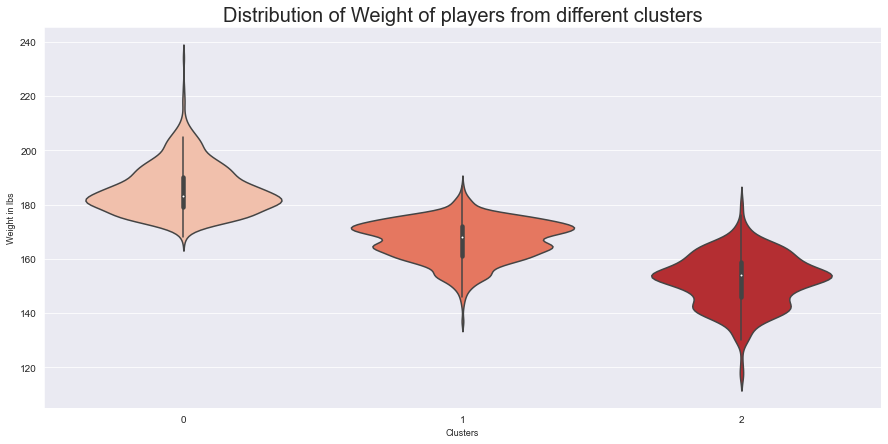

```python
#distribution of weights of playes in different clusters

plt.rcParams['figure.figsize'] = (15, 7)
ax = sns.violinplot(x = Strikers_data['cluster_label'], y = Strikers_data['Weight'], palette = 'Reds')
ax.set_xlabel(xlabel = 'Clusters', fontsize = 9)
ax.set_ylabel(ylabel = 'Weight in lbs', fontsize = 9)
ax.set_title(label = 'Distribution of Weight of players from different clusters', fontsize = 20)
```

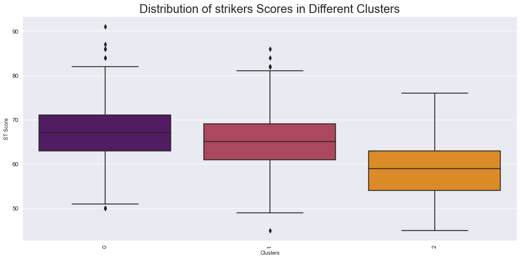

```python
ax = sns.boxplot(x = Strikers_data['cluster_label'], y = Strikers_data['ST_Score'], palette = 'inferno')
ax.set_xlabel(xlabel = 'Clusters', fontsize = 9)
ax.set_ylabel(ylabel = 'ST Score', fontsize = 9)
ax.set_title(label = 'Distribution of strikers Scores in Different Clusters', fontsize = 20)
plt.xticks(rotation = 90)
plt.show()
```

### Understanding Cluster - 0

As shown in the below plots :

-> Most of the players have a high sprint speed , i.e fast players.

-> Examples of players in this Cluster include the Strikers like Javier Hernández , Rubén Castro.

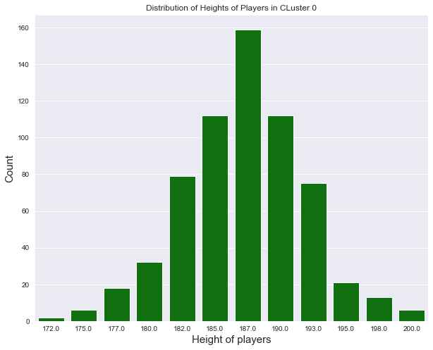

```python
plt.figure(figsize=(10,8))
ax=sns.countplot(cluster_0['Height'],color='green')
ax.set_xlabel(xlabel='Height of players',fontsize=15)
ax.set_ylabel(ylabel='Count',fontsize=15)
ax.set_title(label= 'Distribution of Heights of Players in CLuster 0')
```

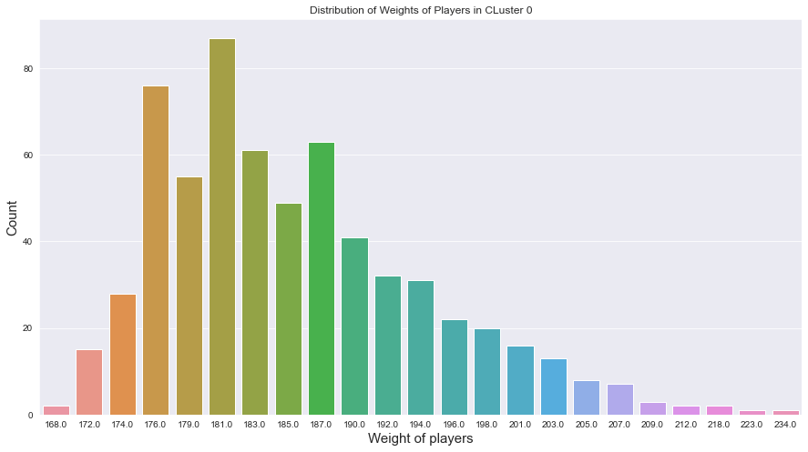

```python
plt.figure(figsize=(15,8))
ax=sns.countplot(cluster_0['Weight'])
ax.set_xlabel(xlabel='Weight of players',fontsize=15)
ax.set_ylabel(ylabel='Count',fontsize=15)
ax.set_title(label= 'Distribution of Weights of Players in CLuster 0')
```

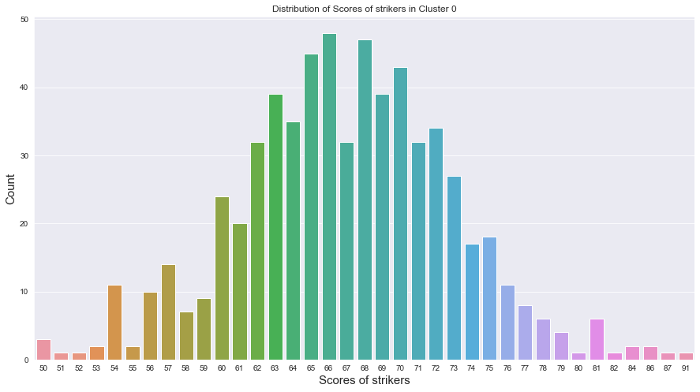

```python
plt.figure(figsize=(15,8))
ax=sns.countplot(cluster_0['ST_Score'])
ax.set_xlabel(xlabel='Scores of strikers',fontsize=15)
ax.set_ylabel(ylabel='Count',fontsize=15)
ax.set_title(label= 'Distribution of Scores of strikers in Cluster 0')
```

```python
cluster_0['ST'].unique()
```

```
array(['91+3', '87+3', '86+3', '84+3', '82+3', '81+3', '81+2', '80+3',
       '79+3', '79+2', '78+2', '77+3', '78+3', '77+2', '76+2', '75+2',
       '75+3', '74+3', '74+2', '73+3', '73+2', '72+2', '71+2', '70+2',
       '69+2', '68+2', '67+2', '66+2', '66+3', '65+2', '64+2', '63+2',
       '62+2', '61+2', '60+2', '59+2', '58+2', '57+2', '56+2', '55+2',
       '54+2', '53+2', '52+2', '50+2', '51+2'], dtype=object)
```

```python
cluster_0['SprintSpeed'].unique()
```

```
array([91., 78., 72., 95., 90., 85., 66., 76., 73., 83., 54., 86., 65.,
       50., 77., 89., 57., 68., 81., 71., 70., 61., 67., 59., 75., 69.,
       34., 64., 63., 62., 60., 55., 74., 32., 58., 47., 79., 46., 53.,
       56., 37., 38., 82., 41., 88., 93., 51., 49., 87., 80., 52., 84.,
       45., 48., 36., 42., 33., 30., 39., 92., 31., 44.])
```

### Understanding Cluster - 1

As shown in the below plots :

-> The second cluster contains tall players,most of the players are above 180 centimeters.

-> Most of the players have a low sprint speed i.e slow players.

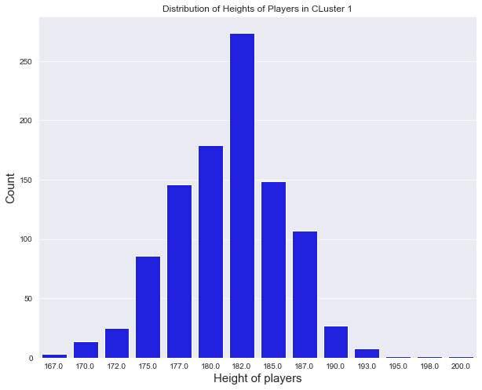

```python
plt.figure(figsize=(10,8))
ax=sns.countplot(cluster_1['Height'],color='blue')
ax.set_xlabel(xlabel='Height of players',fontsize=15)
ax.set_ylabel(ylabel='Count',fontsize=15)
ax.set_title(label= 'Distribution of Heights of Players in CLuster 1')
```

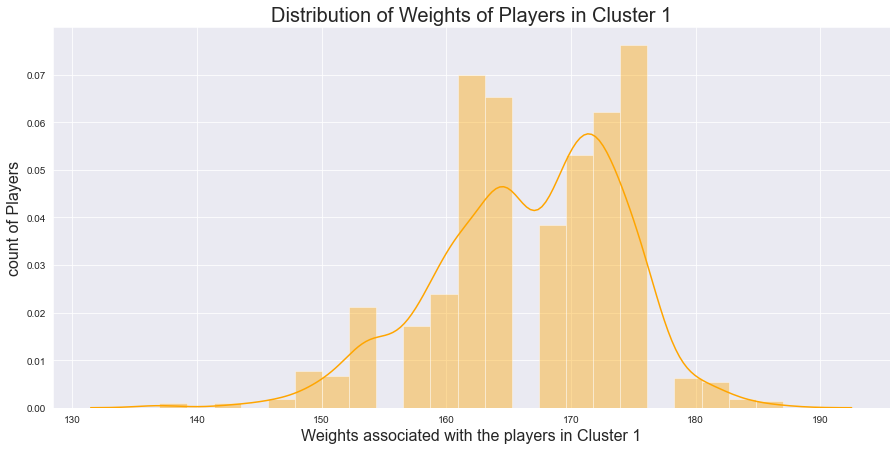

```python
#plt.style.use('_classic_test')
sns.distplot(cluster_1['Weight'], color = 'orange')
plt.title('Distribution of Weights of Players in Cluster 1', fontsize = 20)
plt.xlabel('Weights associated with the players in Cluster 1', fontsize = 16)
plt.ylabel('count of Players', fontsize = 16)
plt.show()
```

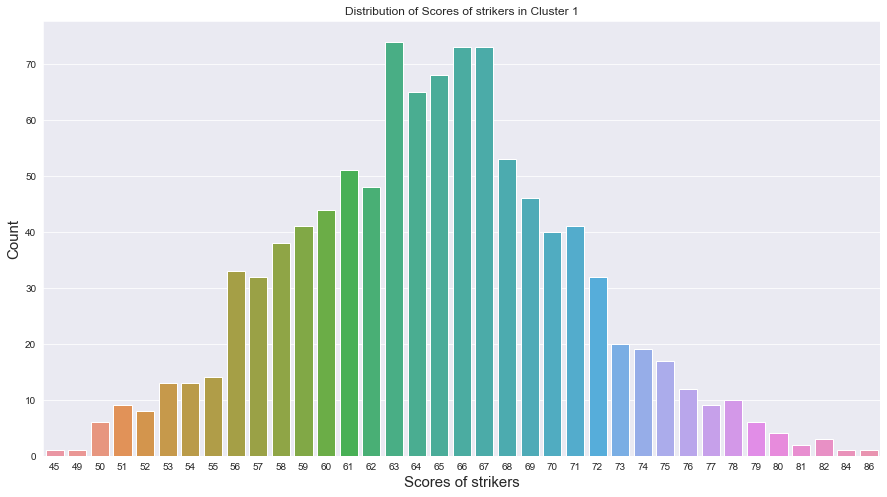

```python
plt.figure(figsize=(15,8))
ax=sns.countplot(cluster_1['ST_Score'])
ax.set_xlabel(xlabel='Scores of strikers',fontsize=15)
ax.set_ylabel(ylabel='Count',fontsize=15)
ax.set_title(label= 'Distribution of Scores of strikers in Cluster 1')
```

```python
cluster_1['ST'].unique()
```

```
array(['86+3', '84+3', '82+3', '80+3', '82+2', '81+2', '78+2', '80+2',
       '79+2', '79+3', '78+3', '77+3', '77+2', '76+2', '75+2', '76+3',
       '74+3', '74+2', '73+2', '71+2', '72+2', '73+3', '70+3', '70+2',
       '69+2', '65+2', '68+2', '67+2', '66+2', '61+2', '64+2', '63+2',
       '62+2', '59+2', '60+2', '57+2', '58+2', '56+2', '55+2', '54+2',
       '53+2', '52+2', '51+2', '50+2', '49+2', '45+2'], dtype=object)
```

```python
cluster_1['SprintSpeed'].unique()
```

```
array([80., 78., 84., 87., 64., 85., 90., 91., 88., 67., 70., 76., 69.,
       82., 83., 79., 73., 75., 89., 74., 77., 53., 39., 81., 62., 72.,
       61., 60., 55., 68., 49., 57., 92., 86., 94., 66., 71., 65., 59.,
       32., 50., 56., 58., 45., 63., 52., 54., 51., 93., 42., 47., 46.,
       48., 40.])
```

### Understanding Cluster - 2

As shown in the below plots :

-> The third cluster contains comparitively short players,most of the players are below 180 centimeters.

-> The third cluster contains strong people and most of the players are having a comparitively less Striker and overall scores,also have 4* international rating.

-> Most of the players have a comparitively high sprint speed.

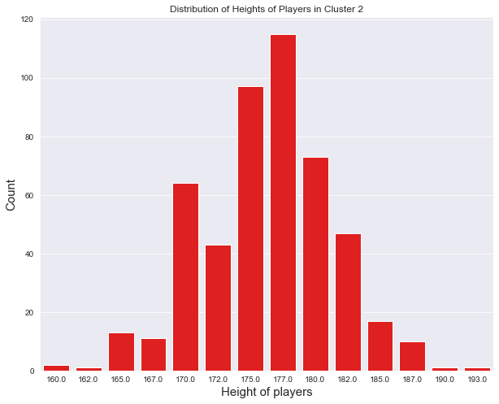

```python
plt.figure(figsize=(10,8))
ax=sns.countplot(cluster_2['Height'],color='red')
ax.set_xlabel(xlabel='Height of players',fontsize=15)
ax.set_ylabel(ylabel='Count',fontsize=15)
ax.set_title(label= 'Distribution of Heights of Players in Cluster 2')
```

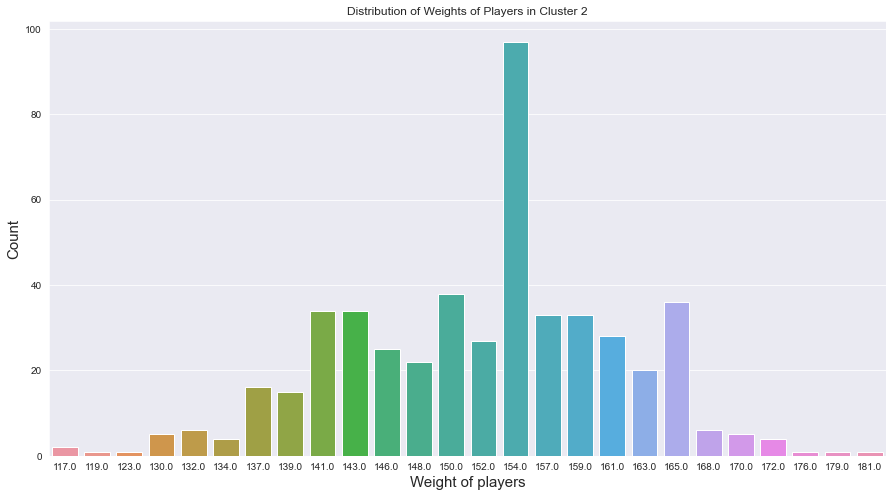

```python
plt.figure(figsize=(15,8))
ax=sns.countplot(cluster_2['Weight'])
ax.set_xlabel(xlabel='Weight of players',fontsize=15)
ax.set_ylabel(ylabel='Count',fontsize=15)
ax.set_title(label= 'Distribution of Weights of Players in Cluster 2')
```

```python
cluster_2['ST'].unique()
```

```
array(['76+3', '76+2', '75+2', '72+2', '74+2', '73+2', '71+2', '70+2',
       '69+2', '68+2', '67+2', '66+2', '65+2', '64+2', '63+2', '59+2',
       '62+2', '61+2', '60+2', '58+2', '53+2', '57+2', '56+2', '55+2',
       '54+2', '52+2', '51+2', '50+2', '49+2', '48+2', '47+2', '45+2'],
      dtype=object)
```

```python
cluster_1['SprintSpeed'].unique()
```

[output not shown]

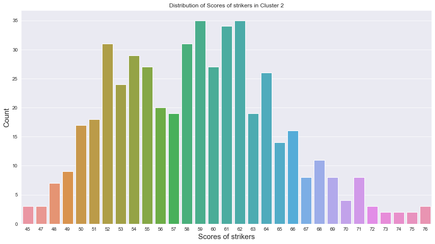

```python
plt.figure(figsize=(15,8))
ax=sns.countplot(cluster_2['ST_Score'])
ax.set_xlabel(xlabel='Scores of strikers',fontsize=15)
ax.set_ylabel(ylabel='Count',fontsize=15)
ax.set_title(label= 'Distribution of Scores of strikers in Cluster 2')
```

# Analysis of Positions and Skillset of FIFA-19 Football players

## Exploratory and Data Analysis

#### Reading the Dataset on FIFA-19

##### data:

This dataset includes details about different football players featured in EA's FIFA 19.

##### positions:

This dataset includes detailed information about the different positions with its full names on a football field.

```python
data = pd.read_excel('2021-06-23_Dataset_Fifa_19.xlsx')
positions = pd.read_excel('fifa19_positions.xlsx')
```

```python
# Dropping columns which are of very less significance.

# data.drop(columns=['Photo', 'Nationality', 'Flag', 'Potential', 'Club Logo','Wage', 'Special',
#                    'International Reputation','Skill Moves','Work Rate','Body Type','Real Face',
#                    'Jersey Number','Joined','Loaned From','Contract Valid Until', 'Release Clause',
#                    'Joined', 'Contract Valid Until'], inplace=True)
```

```python
display(data.head())
display(data.info())
display(data.describe())
```

|  | Order | ID | Name | Age | Photo | Nationality | Flag | Overall | Potential | Club | ... | Composure | Marking | StandingTackle | SlidingTackle | GKDiving | GKHandling | GKKicking | GKPositioning | GKReflexes | Release Clause |
| --- | --- | --- | --- | --- | --- | --- | --- | --- | --- | --- | --- | --- | --- | --- | --- | --- | --- | --- | --- | --- | --- |
| 0 | 0 | 158023 | L. Messi | 31 | https://cdn.sofifa.org/players/4/19/158023.png | Argentina | https://cdn.sofifa.org/flags/52.png | 94 | 94 | FC Barcelona | ... | 96.0 | 33.0 | 28.0 | 26.0 | 6.0 | 11.0 | 15.0 | 14.0 | 8.0 | €226.5M |
| 1 | 1 | 20801 | Cristiano Ronaldo | 33 | https://cdn.sofifa.org/players/4/19/20801.png | Portugal | https://cdn.sofifa.org/flags/38.png | 94 | 94 | Juventus | ... | 95.0 | 28.0 | 31.0 | 23.0 | 7.0 | 11.0 | 15.0 | 14.0 | 11.0 | €127.1M |
| 2 | 2 | 190871 | Neymar Jr | 26 | https://cdn.sofifa.org/players/4/19/190871.png | Brazil | https://cdn.sofifa.org/flags/54.png | 92 | 93 | Paris Saint-Germain | ... | 94.0 | 27.0 | 24.0 | 33.0 | 9.0 | 9.0 | 15.0 | 15.0 | 11.0 | €228.1M |
| 3 | 3 | 193080 | De Gea | 27 | https://cdn.sofifa.org/players/4/19/193080.png | Spain | https://cdn.sofifa.org/flags/45.png | 91 | 93 | Manchester United | ... | 68.0 | 15.0 | 21.0 | 13.0 | 90.0 | 85.0 | 87.0 | 88.0 | 94.0 | €138.6M |
| 4 | 4 | 192985 | K. De Bruyne | 27 | https://cdn.sofifa.org/players/4/19/192985.png | Belgium | https://cdn.sofifa.org/flags/7.png | 91 | 92 | Manchester City | ... | 88.0 | 68.0 | 58.0 | 51.0 | 15.0 | 13.0 | 5.0 | 10.0 | 13.0 | €196.4M |

5 rows × 89 columns

```
<class 'pandas.core.frame.DataFrame'>
RangeIndex: 18207 entries, 0 to 18206
Data columns (total 89 columns):
 #   Column                    Non-Null Count  Dtype
---  ------                    --------------  -----
 0   Order                     18207 non-null  int64
 1   ID                        18207 non-null  int64
 2   Name                      18207 non-null  object
 3   Age                       18207 non-null  int64
 4   Photo                     18207 non-null  object
 5   Nationality               18207 non-null  object
 6   Flag                      18207 non-null  object
 7   Overall                   18207 non-null  int64
 8   Potential                 18207 non-null  int64
 9   Club                      17966 non-null  object
```

[output cut: 81 more lines]

```
None
```

|  | Order | ID | Age | Overall | Potential | Special | International Reputation | Weak Foot | Skill Moves | Jersey Number | ... | Penalties | Composure | Marking | StandingTackle | SlidingTackle | GKDiving | GKHandling | GKKicking | GKPositioning | GKReflexes |
| --- | --- | --- | --- | --- | --- | --- | --- | --- | --- | --- | --- | --- | --- | --- | --- | --- | --- | --- | --- | --- | --- |
| count | 18207.000000 | 18207.000000 | 18207.000000 | 18207.000000 | 18207.000000 | 18179.000000 | 18131.000000 | 18131.000000 | 18131.000000 | 18119.000000 | ... | 18131.000000 | 18131.000000 | 18131.000000 | 18131.000000 | 18131.000000 | 18131.000000 | 18131.000000 | 18131.000000 | 18131.000000 | 18131.000000 |
| mean | 9103.000000 | 214298.338606 | 25.122206 | 66.238699 | 71.307299 | 1597.947907 | 1.113397 | 2.947217 | 2.361701 | 19.544401 | ... | 48.560807 | 58.658541 | 47.276212 | 47.697149 | 45.660030 | 16.618057 | 16.393194 | 16.231758 | 16.390822 | 16.710937 |
| std | 5256.052511 | 29965.244204 | 4.669943 | 6.908930 | 6.136496 | 272.585019 | 0.394310 | 0.660462 | 0.756292 | 15.952570 | ... | 15.706617 | 11.432878 | 19.909676 | 21.670806 | 21.296616 | 17.697405 | 16.909519 | 16.503546 | 17.037065 | 17.960529 |
| min | 0.000000 | 16.000000 | 16.000000 | 46.000000 | 48.000000 | 731.000000 | 1.000000 | 1.000000 | 1.000000 | 1.000000 | ... | 5.000000 | 3.000000 | 3.000000 | 2.000000 | 3.000000 | 1.000000 | 1.000000 | 1.000000 | 1.000000 | 1.000000 |
| 25% | 4551.500000 | 200315.500000 | 21.000000 | 62.000000 | 67.000000 | 1458.000000 | 1.000000 | 3.000000 | 2.000000 | 8.000000 | ... | 39.000000 | 51.000000 | 30.000000 | 27.000000 | 24.000000 | 8.000000 | 8.000000 | 8.000000 | 8.000000 | 8.000000 |
| 50% | 9103.000000 | 221759.000000 | 25.000000 | 66.000000 | 71.000000 | 1635.000000 | 1.000000 | 3.000000 | 2.000000 | 17.000000 | ... | 49.000000 | 60.000000 | 53.000000 | 55.000000 | 52.000000 | 11.000000 | 11.000000 | 11.000000 | 11.000000 | 11.000000 |
| 75% | 13654.500000 | 236529.500000 | 28.000000 | 71.000000 | 75.000000 | 1787.000000 | 1.000000 | 3.000000 | 3.000000 | 26.000000 | ... | 60.000000 | 67.000000 | 64.000000 | 66.000000 | 64.000000 | 14.000000 | 14.000000 | 14.000000 | 14.000000 | 14.000000 |
| max | 18206.000000 | 246620.000000 | 45.000000 | 94.000000 | 95.000000 | 2346.000000 | 5.000000 | 5.000000 | 5.000000 | 99.000000 | ... | 92.000000 | 96.000000 | 94.000000 | 93.000000 | 91.000000 | 90.000000 | 92.000000 | 91.000000 | 90.000000 | 94.000000 |

8 rows × 44 columns

```python
display(positions)
```

|  | Position | Description | Zone |
| --- | --- | --- | --- |
| 0 | GK | Goal Keeper | GoalKeeper |
| 1 | CB | Centre Back | Defense |
| 2 | LCB | Left Centre Back | Defense |
| 3 | RCB | Right Centre Back | Defense |
| 4 | LB | Left Back | Defense |
| 5 | RB | Right Back | Defense |
| 6 | LWB | Left Wing Back | Defense |
| 7 | RWB | Right Wing Back | Defense |
| 8 | CDM | Centre Defensive Midfielder | Midfield |
| 9 | LDM | Left Defensive Midfielder | Midfield |
| 10 | RDM | Right Defensive Midfielder | Midfield |
| 11 | CM | Centre Midfielder | Midfield |
| 12 | LCM | Left Centre Midfielder | Midfield |
| 13 | RCM | Right Centre Midfielder | Midfield |
| 14 | LM | Left Midfielder | Midfield |
| 15 | RM | Right Midfielder | Midfield |
| 16 | CAM | Centre Attacking Midfielder | Midfield |
| 17 | LAM | Left Attacking Midfielder | Midfield |
| 18 | RAM | Right Attacking Midfielder | Midfield |
| 19 | LW | Left Winger | Midfield |
| 20 | RW | Right Winger | Midfield |
| 21 | CF | Centre Fordward | Attack |
| 22 | LF | Left Fordward | Attack |
| 23 | RF | Right Forward | Attack |
| 24 | ST | Striker | Attack |
| 25 | LS | Left Striker | Attack |
| 26 | RS | Right Striker | Attack |

### Profiling

Generates profile reports from a pandas DataFrame. The pandas df.describe() function is great but a little basic for serious exploratory data analysis. For each column the following statistics - if relevant for the column type - are presented in an interactive HTML report:</br>

```python
#pp.ProfileReport(data)
```

Grouping data based on the 'Position'

```python
posData = data.groupby("Position").count()
posData = posData.sort_values(by = "Order", ascending = True)

# Data required to create horizontal bar chart data
bars = list(posData.index)
y_pos = np.arange(len(bars))
values = list(posData["Order"].values)
```

```python
# Palette by positions dictionary
posPalette = dict()
posPalette["GoalKeeper"] = "#dc3912"
posPalette["Defense"] = "#3366cc"
posPalette["Midfield"] = "#ff9900"
posPalette["Attack"] = "#109618"

# Colors by positions dictionary
posColors = dict()
for ix in range(len(positions)):
    pos = positions.Position[ix]
    zone = positions.Zone[ix]
    posColors[pos] = posPalette[zone]
```

## Horizontal Barchart to determine the number of players per position

The number of football players can be distinguished based on thier positions. It is found that most of the players per individual positions are the Strikers followed by Goalkeepers and then centre back players.

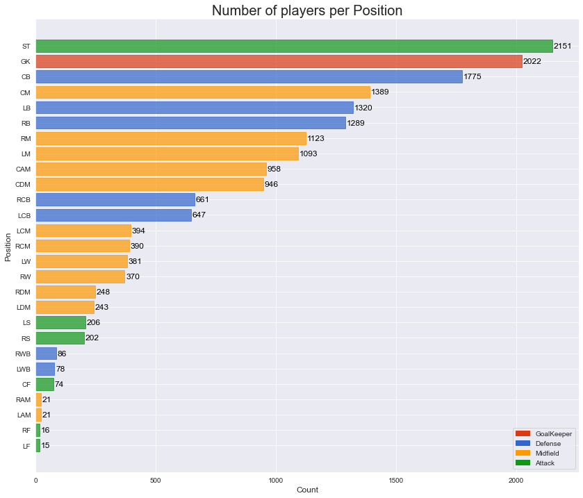

```python
# Set up the matplotlib figure
fig, ax0 = plt.subplots(figsize = (14, 12))

# Horizontal barchart
barlist = plt.barh(y_pos, values, alpha = 0.7)
plt.yticks(y_pos, bars)
plt.title("Number of players per Position", fontsize = 20)

# Add bar labels
for i, v in enumerate(values):
    ax0.text(v + 5, i - .15, str(v), color = "black", fontweight = "normal", fontsize = 12)
    barlist[i].set_color(posColors[bars[i]])

# Add custom legend
gk_patch = mpatches.Patch(color = "#dc3912", label = "GoalKeeper")
df_patch = mpatches.Patch(color = "#3366cc", label = "Defense")
mf_patch = mpatches.Patch(color = "#ff9900", label = "Midfield")
at_patch = mpatches.Patch(color = "#109618", label = "Attack")
plt.legend(handles = [gk_patch, df_patch, mf_patch, at_patch])

# Plot setup
plt.xlabel("Count", fontsize = 12)
plt.ylabel("Position", fontsize = 12)
plt.show()
```

```python
# Calculate the number of players per zone
zoneData = dict()
for ix1 in range(len(positions)):
    pos1 = positions.Position[ix1]

    for ix2 in range(len(posData)):
        pos2 = posData.index[ix2]

        if pos1 == pos2:
            zone = positions.Zone[ix1]
            count = posData.Order[ix2]

            if zone in zoneData:
                zoneData[zone] += count
            else:
                zoneData[zone] = count
            break;
zoneData
```

```
{'GoalKeeper': 2022, 'Defense': 5856, 'Midfield': 7577, 'Attack': 2664}
```

```python
# Sorting dictionary in ascending order based on values
zoneData = OrderedDict(sorted(zoneData.items(), key = lambda kv: kv[1], reverse = False))
zoneData
```

```
OrderedDict([('GoalKeeper', 2022),
             ('Attack', 2664),
             ('Defense', 5856),
             ('Midfield', 7577)])
```

# Horizontal Barchart for determine the number of players per zone

The number of football players can be distinguished based on thier zones. It is found that most of the players per individual zones are the Midfielders followed by Defensive players and then the Attackers.

```python
# Create horizontal bar chart data
bars = list(zoneData.keys())
y_pos = np.arange(len(zoneData))
values = list(zoneData.values())
```

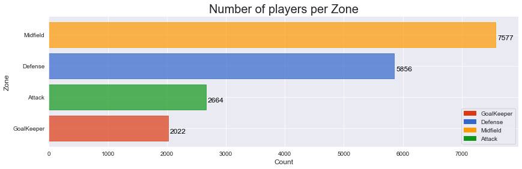

```python
# Set up the matplotlib figure
fig, ax1 = plt.subplots(figsize = (14, 4))

# Horizontal barchart
barlist = plt.barh(y_pos, values, alpha = 0.7)
plt.yticks(y_pos, bars)
plt.title("Number of players per Zone", fontsize = 20)

# Add bar labels
for i, v in enumerate(values):
    ax1.text(v + 30, i - .15, str(v), color = "black", fontweight = "normal", fontsize = 12)
    barlist[i].set_color(posPalette[bars[i]])

# Add custom legend
gk_patch = mpatches.Patch(color = "#dc3912", label = "GoalKeeper")
df_patch = mpatches.Patch(color = "#3366cc", label = "Defense")
mf_patch = mpatches.Patch(color = "#ff9900", label = "Midfield")
at_patch = mpatches.Patch(color = "#109618", label = "Attack")
plt.legend(handles = [gk_patch, df_patch, mf_patch, at_patch])

# Plot setup
plt.xlabel("Count", fontsize = 12)
plt.ylabel("Zone", fontsize = 12)
plt.show()
```

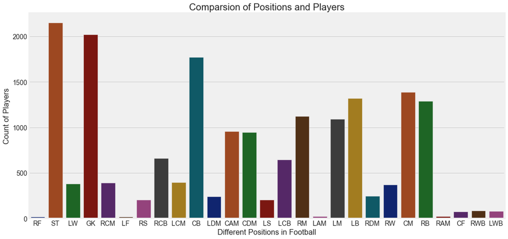

```python
#different positions acquired by the players

plt.figure(figsize = (18,8))
plt.style.use('fivethirtyeight')
ax = sns.countplot('Position', data = data, palette = 'dark')
ax.set_xlabel(xlabel = 'Different Positions in Football', fontsize = 16)
ax.set_ylabel(ylabel = 'Count of Players', fontsize = 16)
ax.set_title(label = 'Comparsion of Positions and Players', fontsize = 20)
plt.show()
```

```python
data.select_dtypes(include=object).columns
data['Value'] = data['Value'].astype(str)
data['Wage'] = data['Wage'].astype(str)
```

```python
#Function to convert value and wage of the player.
def currencyConverter(val):
    if (val[-1] == 'M'):
        val = val[1:-1]
        val = float(val) * 1000000
        return val

    elif (val[-1] == 'K'):
        val = val[1:-1]
        val = float(val) * 1000
        return val

    else:
        return 0
```

```python
data['Value in Pounds'] = data['Value'].apply(currencyConverter)
data['Wage in Pounds'] = data['Wage'].apply(currencyConverter)

data.drop(columns=['Value', 'Wage'], inplace=True)

data.head()
```

|  | Order | ID | Name | Age | Photo | Nationality | Flag | Overall | Potential | Club | ... | StandingTackle | SlidingTackle | GKDiving | GKHandling | GKKicking | GKPositioning | GKReflexes | Release Clause | Value in Pounds | Wage in Pounds |
| --- | --- | --- | --- | --- | --- | --- | --- | --- | --- | --- | --- | --- | --- | --- | --- | --- | --- | --- | --- | --- | --- |
| 0 | 0 | 158023 | L. Messi | 31 | https://cdn.sofifa.org/players/4/19/158023.png | Argentina | https://cdn.sofifa.org/flags/52.png | 94 | 94 | FC Barcelona | ... | 28.0 | 26.0 | 6.0 | 11.0 | 15.0 | 14.0 | 8.0 | €226.5M | 110500000.0 | 565000.0 |
| 1 | 1 | 20801 | Cristiano Ronaldo | 33 | https://cdn.sofifa.org/players/4/19/20801.png | Portugal | https://cdn.sofifa.org/flags/38.png | 94 | 94 | Juventus | ... | 31.0 | 23.0 | 7.0 | 11.0 | 15.0 | 14.0 | 11.0 | €127.1M | 77000000.0 | 405000.0 |
| 2 | 2 | 190871 | Neymar Jr | 26 | https://cdn.sofifa.org/players/4/19/190871.png | Brazil | https://cdn.sofifa.org/flags/54.png | 92 | 93 | Paris Saint-Germain | ... | 24.0 | 33.0 | 9.0 | 9.0 | 15.0 | 15.0 | 11.0 | €228.1M | 118500000.0 | 290000.0 |
| 3 | 3 | 193080 | De Gea | 27 | https://cdn.sofifa.org/players/4/19/193080.png | Spain | https://cdn.sofifa.org/flags/45.png | 91 | 93 | Manchester United | ... | 21.0 | 13.0 | 90.0 | 85.0 | 87.0 | 88.0 | 94.0 | €138.6M | 72000000.0 | 260000.0 |
| 4 | 4 | 192985 | K. De Bruyne | 27 | https://cdn.sofifa.org/players/4/19/192985.png | Belgium | https://cdn.sofifa.org/flags/7.png | 91 | 92 | Manchester City | ... | 58.0 | 51.0 | 15.0 | 13.0 | 5.0 | 10.0 | 13.0 | €196.4M | 102000000.0 | 355000.0 |

5 rows × 89 columns

# Conversion of Skills into proper format

```python
data[['LS', 'ST', 'RS', 'LW', 'LF', 'CF', 'RF', 'RW', 'LAM', 'CAM',
       'RAM', 'LM', 'LCM', 'CM', 'RCM', 'RM', 'LWB', 'LDM', 'CDM', 'RDM',
       'RWB', 'LB', 'LCB', 'CB', 'RCB', 'RB']].head()
```

|  | LS | ST | RS | LW | LF | CF | RF | RW | LAM | CAM | ... | LWB | LDM | CDM | RDM | RWB | LB | LCB | CB | RCB | RB |
| --- | --- | --- | --- | --- | --- | --- | --- | --- | --- | --- | --- | --- | --- | --- | --- | --- | --- | --- | --- | --- | --- |
| 0 | 88+2 | 88+2 | 88+2 | 92+2 | 93+2 | 93+2 | 93+2 | 92+2 | 93+2 | 93+2 | ... | 64+2 | 61+2 | 61+2 | 61+2 | 64+2 | 59+2 | 47+2 | 47+2 | 47+2 | 59+2 |
| 1 | 91+3 | 91+3 | 91+3 | 89+3 | 90+3 | 90+3 | 90+3 | 89+3 | 88+3 | 88+3 | ... | 65+3 | 61+3 | 61+3 | 61+3 | 65+3 | 61+3 | 53+3 | 53+3 | 53+3 | 61+3 |
| 2 | 84+3 | 84+3 | 84+3 | 89+3 | 89+3 | 89+3 | 89+3 | 89+3 | 89+3 | 89+3 | ... | 65+3 | 60+3 | 60+3 | 60+3 | 65+3 | 60+3 | 47+3 | 47+3 | 47+3 | 60+3 |
| 3 | NaN | NaN | NaN | NaN | NaN | NaN | NaN | NaN | NaN | NaN | ... | NaN | NaN | NaN | NaN | NaN | NaN | NaN | NaN | NaN | NaN |
| 4 | 82+3 | 82+3 | 82+3 | 87+3 | 87+3 | 87+3 | 87+3 | 87+3 | 88+3 | 88+3 | ... | 77+3 | 77+3 | 77+3 | 77+3 | 77+3 | 73+3 | 66+3 | 66+3 | 66+3 | 73+3 |

5 rows × 26 columns

```python
#Function to convert skill rating at each position.
def skillConverter(val):
    if type(val) == str:
        s1 = val[0:2]
        s2 = val[-1]
        val = int(s1) + int(s2)
        return val

    else:
        return val
```

```python
skill_columns = ['LS', 'ST', 'RS', 'LW', 'LF', 'CF', 'RF', 'RW', 'LAM', 'CAM',
       'RAM', 'LM', 'LCM', 'CM', 'RCM', 'RM', 'LWB', 'LDM', 'CDM', 'RDM',
       'RWB', 'LB', 'LCB', 'CB', 'RCB', 'RB']

for col in skill_columns:
    data[col] = data[col].apply(skillConverter)
```

```python
data[['LS', 'ST', 'RS', 'LW', 'LF', 'CF', 'RF', 'RW', 'LAM', 'CAM',
       'RAM', 'LM', 'LCM', 'CM', 'RCM', 'RM', 'LWB', 'LDM', 'CDM', 'RDM',
       'RWB', 'LB', 'LCB', 'CB', 'RCB', 'RB']].head()
```

|  | LS | ST | RS | LW | LF | CF | RF | RW | LAM | CAM | ... | LWB | LDM | CDM | RDM | RWB | LB | LCB | CB | RCB | RB |
| --- | --- | --- | --- | --- | --- | --- | --- | --- | --- | --- | --- | --- | --- | --- | --- | --- | --- | --- | --- | --- | --- |
| 0 | 90.0 | 90.0 | 90.0 | 94.0 | 95.0 | 95.0 | 95.0 | 94.0 | 95.0 | 95.0 | ... | 66.0 | 63.0 | 63.0 | 63.0 | 66.0 | 61.0 | 49.0 | 49.0 | 49.0 | 61.0 |
| 1 | 94.0 | 94.0 | 94.0 | 92.0 | 93.0 | 93.0 | 93.0 | 92.0 | 91.0 | 91.0 | ... | 68.0 | 64.0 | 64.0 | 64.0 | 68.0 | 64.0 | 56.0 | 56.0 | 56.0 | 64.0 |
| 2 | 87.0 | 87.0 | 87.0 | 92.0 | 92.0 | 92.0 | 92.0 | 92.0 | 92.0 | 92.0 | ... | 68.0 | 63.0 | 63.0 | 63.0 | 68.0 | 63.0 | 50.0 | 50.0 | 50.0 | 63.0 |
| 3 | NaN | NaN | NaN | NaN | NaN | NaN | NaN | NaN | NaN | NaN | ... | NaN | NaN | NaN | NaN | NaN | NaN | NaN | NaN | NaN | NaN |
| 4 | 85.0 | 85.0 | 85.0 | 90.0 | 90.0 | 90.0 | 90.0 | 90.0 | 91.0 | 91.0 | ... | 80.0 | 80.0 | 80.0 | 80.0 | 80.0 | 76.0 | 69.0 | 69.0 | 69.0 | 76.0 |

5 rows × 26 columns

# Dealing with invalid data in the body type field

```python
data['Body Type'].unique()
```

```
array(['Messi', 'C. Ronaldo', 'Neymar', 'Lean', 'Normal', 'Courtois',
       'Stocky', 'PLAYER_BODY_TYPE_25', 'Shaqiri', nan, 'Akinfenwa'],
      dtype=object)
```

```python
data['Body Type'][data['Body Type'] == 'Messi'] = 'Lean'
data['Body Type'][data['Body Type'] == 'C. Ronaldo'] = 'Normal'
data['Body Type'][data['Body Type'] == 'Neymar'] = 'Lean'
data['Body Type'][data['Body Type'] == 'Courtois'] = 'Lean'
#PLAYER_BODY_TYPE_25 is the body type of Mohammed Salah who has a Normal body type.
data['Body Type'][data['Body Type'] == 'PLAYER_BODY_TYPE_25'] = 'Normal'
data['Body Type'][data['Body Type'] == 'Shaqiri'] = 'Stocky'
data['Body Type'][data['Body Type'] == 'Akinfenwa'] = 'Stocky'
```

```python
print(data['Position'].unique())
print(data['Position'].nunique())
```

```
['RF' 'ST' 'LW' 'GK' 'RCM' 'LF' 'RS' 'RCB' 'LCM' 'CB' 'LDM' 'CAM' 'CDM'
 'LS' 'LCB' 'RM' 'LAM' 'LM' 'LB' 'RDM' 'RW' 'CM' 'RB' 'RAM' 'CF' 'RWB' nan
 'LWB']
27
```

## Selection of players with who are 'Strikers', 'Centre Defensive Midfielders' and 'GoalKeepers'

Filtering the data for finding the main differences between the players who are "ST", "CDM" and "GK".

```python
position_df = data[(data['Position'] == 'ST') | (data['Position'] == 'CDM') | (data['Position'] == 'GK')]
position_df
```

|  | Order | ID | Name | Age | Photo | Nationality | Flag | Overall | Potential | Club | ... | StandingTackle | SlidingTackle | GKDiving | GKHandling | GKKicking | GKPositioning | GKReflexes | Release Clause | Value in Pounds | Wage in Pounds |
| --- | --- | --- | --- | --- | --- | --- | --- | --- | --- | --- | --- | --- | --- | --- | --- | --- | --- | --- | --- | --- | --- |
| 1 | 1 | 20801 | Cristiano Ronaldo | 33 | https://cdn.sofifa.org/players/4/19/20801.png | Portugal | https://cdn.sofifa.org/flags/38.png | 94 | 94 | Juventus | ... | 31.0 | 23.0 | 7.0 | 11.0 | 15.0 | 14.0 | 11.0 | €127.1M | 77000000.0 | 405000.0 |
| 3 | 3 | 193080 | De Gea | 27 | https://cdn.sofifa.org/players/4/19/193080.png | Spain | https://cdn.sofifa.org/flags/45.png | 91 | 93 | Manchester United | ... | 21.0 | 13.0 | 90.0 | 85.0 | 87.0 | 88.0 | 94.0 | €138.6M | 72000000.0 | 260000.0 |
| 9 | 9 | 200389 | J. Oblak | 25 | https://cdn.sofifa.org/players/4/19/200389.png | Slovenia | https://cdn.sofifa.org/flags/44.png | 90 | 93 | Atlético Madrid | ... | 12.0 | 18.0 | 86.0 | 92.0 | 78.0 | 88.0 | 89.0 | €144.5M | 68000000.0 | 94000.0 |
| 10 | 10 | 188545 | R. Lewandowski | 29 | https://cdn.sofifa.org/players/4/19/188545.png | Poland | https://cdn.sofifa.org/flags/37.png | 90 | 90 | FC Bayern München | ... | 42.0 | 19.0 | 15.0 | 6.0 | 12.0 | 8.0 | 10.0 | €127.1M | 77000000.0 | 205000.0 |
| 16 | 16 | 202126 | H. Kane | 24 | https://cdn.sofifa.org/players/4/19/202126.png | England | https://cdn.sofifa.org/flags/14.png | 89 | 91 | Tottenham Hotspur | ... | 36.0 | 38.0 | 8.0 | 10.0 | 11.0 | 14.0 | 11.0 | €160.7M | 83500000.0 | 205000.0 |
| ... | ... | ... | ... | ... | ... | ... | ... | ... | ... | ... | ... | ... | ... | ... | ... | ... | ... | ... | ... | ... | ... |
| 18194 | 18194 | 245862 | J. Milli | 18 | https://cdn.sofifa.org/players/4/19/245862.png | Italy | https://cdn.sofifa.org/flags/27.png | 47 | 65 | Lecce | ... | 10.0 | 11.0 | 52.0 | 52.0 | 52.0 | 40.0 | 44.0 | €109K | 50000.0 | 1000.0 |
| 18198 | 18198 | 242844 | J. Livesey | 18 | https://cdn.sofifa.org/players/4/19/242844.png | England | https://cdn.sofifa.org/flags/14.png | 47 | 70 | Burton Albion | ... | 11.0 | 13.0 | 46.0 | 52.0 | 58.0 | 42.0 | 48.0 | €165K | 60000.0 | 1000.0 |
| 18200 | 18200 | 231381 | J. Young | 18 | https://cdn.sofifa.org/players/4/19/231381.png | Scotland | https://cdn.sofifa.org/flags/42.png | 47 | 62 | Swindon Town | ... | 17.0 | 14.0 | 11.0 | 15.0 | 12.0 | 12.0 | 11.0 | €143K | 60000.0 | 1000.0 |
| 18203 | 18203 | 243165 | N. Christoffersson | 19 | https://cdn.sofifa.org/players/4/19/243165.png | Sweden | https://cdn.sofifa.org/flags/46.png | 47 | 63 | Trelleborgs FF | ... | 15.0 | 19.0 | 10.0 | 9.0 | 9.0 | 5.0 | 12.0 | €113K | 60000.0 | 1000.0 |
| 18204 | 18204 | 241638 | B. Worman | 16 | https://cdn.sofifa.org/players/4/19/241638.png | England | https://cdn.sofifa.org/flags/14.png | 47 | 67 | Cambridge United | ... | 13.0 | 11.0 | 6.0 | 5.0 | 10.0 | 6.0 | 13.0 | €165K | 60000.0 | 1000.0 |

5119 rows × 89 columns

## Piechart Visualization for determining the distribution of the players positive-wise

The below piechart shows that there are more players who are Strikers about 42% followed by Goalkeepers and then Centre defensive Midfielders

```python
pie_vis1 = go.Pie(values=position_df['Position'].value_counts().values,
                labels=position_df['Position'].value_counts().index.values,
                hole=0.3
               )


layout = go.Layout(title={
        'text': "<b>Distribution of Players Position-Wise</b>",
        'y':0.9,
        'x':0.5,
        'xanchor': 'center',
        'yanchor': 'top'})

fig = go.Figure(data=[pie_vis1], layout=layout)
py.iplot(fig)
```

[interactive chart not shown]

## Piechart Visualization for determining the distribution of the players positive-wise

The below piechart shows that there are majority of the players prefer their right foot compared to the left.

```python
pie_vis2 = go.Pie(values=position_df['Preferred Foot'].value_counts().values,
                 labels=position_df['Preferred Foot'].value_counts().index.values,
                 hole=0.3
                )


layout = go.Layout(title={
        'text': "<b>Preferred Foot</b>",
        'y':0.9,
        'x':0.5,
        'xanchor': 'center',
        'yanchor': 'top'})

fig = go.Figure(data=[pie_vis2], layout=layout)
py.iplot(fig)
```

[interactive chart not shown]

## Boxplot Visualization of Work Rate vs Overall

The below boxplot shows that the players have almost similar Overall ratings across different work rates

```python
box_vis = go.Box(x=position_df['Work Rate'],
                y=position_df['Overall']
               )

layout = go.Layout(title={
        'text': "<b>Work Rate vs Overall</b>",
        'y':0.9,
        'x':0.5,
        'xanchor': 'center',
        'yanchor': 'top'},
         xaxis=dict(title='<b><i>Work Rate</b></i>'),
         yaxis=dict(title='<b><i>Overall</b></i>'))

fig = go.Figure(data=[box_vis], layout=layout)
py.iplot(fig)
```

[interactive chart not shown]

```python
box_vis2 = go.Box(x=position_df['Body Type'],
                y=position_df['Overall']
               )

layout = go.Layout(title={
        'text': "<b>Body Type vs Overall</b>",
        'y':0.9,
        'x':0.5,
        'xanchor': 'center',
        'yanchor': 'top'},
         xaxis=dict(title='<b><i>Body Type</b></i>'),
         yaxis=dict(title='<b><i>Overall</b></i>'))

fig2 = go.Figure(data=[box_vis2], layout=layout)
py.iplot(fig2)
```

[interactive chart not shown]

### Polar Chart Visualization: Main differences between players with the position “ST” (forward), players with the position “CDM” (center defensive midfielder), and players with the position “GK” (goalkeeper)

Scatterpolar visualization provides an overview of the attributes of the different players. It can used to clearly distinguish between different skills set and the player type based on the position.

Distinction of the players by choosing 6 attributes 'Crossing', 'Finishing', 'FKAccuracy','StandingTackle', 'Marking' and 'Interceptions'.Data is grouped by Position and average is calculated based on these 6 attributes. It is found that Strikers are far better at Finishing compared with other attributes whereas the Centre Defensive Midfielders are better at Tackling, Marking and Interceptions and goalkeepers are not involved in field activities which makes them less in these attributes.

```python
df_skills = position_df.groupby(by='Position')['Crossing', 'Finishing', 'FKAccuracy',
                            'StandingTackle', 'Marking', 'Interceptions'].mean().reset_index()
```

```python
trace5a = go.Scatterpolar(theta=['Crossing', 'Finishing', 'FKAccuracy',
                                 'StandingTackle', 'Marking', 'Interceptions',
                                 'Crossing'
                                ],
                          r=df_skills[df_skills['Position'] == 'ST'][['Crossing', 'Finishing', 'FKAccuracy',
                                                                     'StandingTackle', 'Marking', 'Interceptions',
                                                                     'Crossing'
                                                                    ]].values[0],
                          fill='toself',
                          name='Strikers'
                         )

trace5b = go.Scatterpolar(theta=['Crossing', 'Finishing', 'FKAccuracy',
                                 'StandingTackle', 'Marking', 'Interceptions',
                                 'Crossing'
                                ],
                          r=df_skills[df_skills['Position'] == 'CDM'][['Crossing', 'Finishing', 'FKAccuracy',
                                                                     'StandingTackle', 'Marking', 'Interceptions',
                                                                     'Crossing'
                                                                    ]].values[0],
                          fill='toself',
                          name='Center Defensive Midfielders'
                         )

trace5c = go.Scatterpolar(theta=['Crossing', 'Finishing', 'FKAccuracy',
                                 'StandingTackle', 'Marking', 'Interceptions',
                                 'Crossing'
                                ],
                          r=df_skills[df_skills['Position'] == 'GK'][['Crossing', 'Finishing', 'FKAccuracy',
                                                                     'StandingTackle', 'Marking', 'Interceptions',
                                                                     'Crossing'
                                                                    ]].values[0],
                          fill='toself',
                          name='Goal Keepers'
                         )

layout = go.Layout(polar=dict(radialaxis=dict(visible=True,
                                              range=[0, 100]
                                             )

                             ),
                   showlegend=True,
                   title={
        'text': "<b>1-Differences between Strikers, Center Defensive Midfielders and Goal Keepers</b>",
        'y':0.9,
        'x':0.46,
        'xanchor': 'center',
        'yanchor': 'top'},
         xaxis=dict(title='<b><i>Work Rate</b></i>'),
         yaxis=dict(title='<b><i>Overall</b></i>'))

fig = go.Figure(data=[trace5a, trace5b, trace5c], layout=layout)
py.iplot(fig)
```

[interactive chart not shown]

### Polar Chart Visualization 2: Main differences between players with the position “ST” (forward), players with the position “CDM” (center defensive midfielder), and players with the position “GK” (goalkeeper)

```python
df_skills1 = position_df.groupby(by='Position')['HeadingAccuracy', 'ShortPassing', 'Dribbling',
                                 'LongPassing', 'SprintSpeed','Aggression'].mean().reset_index()
```

```python
trace6a = go.Scatterpolar(theta=['HeadingAccuracy', 'ShortPassing', 'Dribbling',
                                 'LongPassing', 'SprintSpeed',
                                 'Aggression'
                                ],
                          r=df_skills1[df_skills1['Position'] == 'ST']
                          [['HeadingAccuracy', 'ShortPassing', 'Dribbling',
                            'LongPassing', 'SprintSpeed','Aggression']].values[0],
                          fill='toself',
                          name='Strikers'
                         )

trace6b = go.Scatterpolar(theta=['HeadingAccuracy', 'ShortPassing', 'Dribbling',
                                 'LongPassing', 'SprintSpeed',
                                 'Aggression'
                                ],
                          r=df_skills1[df_skills1['Position'] == 'CDM']
                          [['HeadingAccuracy', 'ShortPassing', 'Dribbling',
                            'LongPassing', 'SprintSpeed','Aggression']].values[0],
                          fill='toself',
                          name='Center Defensive Midfielders'
                         )

trace6c = go.Scatterpolar(theta=['HeadingAccuracy', 'ShortPassing', 'Dribbling',
                                 'LongPassing', 'SprintSpeed',
                                 'Aggression'
                                ],
                          r=df_skills1[df_skills1['Position'] == 'GK']
                          [['HeadingAccuracy', 'ShortPassing', 'Dribbling',
                            'LongPassing','SprintSpeed','Aggression']].values[0],
                          fill='toself',
                          name='Goal Keepers'
                         )

layout = go.Layout(polar=dict(radialaxis=dict(visible=True,
                                              range=[0, 100]
                                             )

                             ),
                   showlegend=True,
                                      title={
        'text': "<b>2-Differences between Strikers, Center Defensive Midfielders and Goal Keepers</b>",
        'y':0.9,
        'x':0.46,
        'xanchor': 'center',
        'yanchor': 'top'}
                  )

fig = go.Figure(data=[trace6a, trace6b, trace6c], layout=layout)
py.iplot(fig)
```

[interactive chart not shown]

### Polar Chart Visualization-3: Main differences between players with the position “ST” (forward), players with the position “CDM” (center defensive midfielder), and players with the position “GK” (goalkeeper)

Distinction of the players by choosing 6 attributes 'Agility', 'Positioning', 'Jumping','Stamina', 'Strength' and 'Vision'. Data is grouped by position and average is calculated based on these 6 attributes.It is found that Strikers and Centre Defensive Midfielders almost have the similar characteristics of these 6 attributes except for position where Strikers dominate here. Goal keepers have slightly less stamina and vision compared with the other two types of players.

```python
df_skills2 = position_df.groupby(by='Position')['Agility', 'Positioning', 'Jumping',
                                 'Stamina', 'Strength', 'Vision'].mean().reset_index()
```

```python
trace7a = go.Scatterpolar(theta=['Agility', 'Positioning', 'Jumping',
                                 'Stamina', 'Strength', 'Vision'
                                ],
                          r=df_skills2[df_skills2['Position'] == 'ST']
                          [['Agility', 'Positioning', 'Jumping',
                                 'Stamina', 'Strength', 'Vision']].values[0],
                          fill='toself',
                          name='Strikers'
                         )

trace7b = go.Scatterpolar(theta=['Agility', 'Positioning', 'Jumping',
                                 'Stamina', 'Strength', 'Vision'
                                ],
                          r=df_skills2[df_skills2['Position'] == 'CDM']
                          [['Agility', 'Positioning', 'Jumping',
                                 'Stamina', 'Strength', 'Vision']].values[0],
                          fill='toself',
                          name='Center Defensive Midfielders'
                         )

trace7c = go.Scatterpolar(theta=['Agility', 'Positioning', 'Jumping',
                                 'Stamina', 'Strength', 'Vision'
                                ],
                          r=df_skills2[df_skills2['Position'] == 'GK']
                          [['Agility', 'Positioning', 'Jumping',
                                 'Stamina', 'Strength', 'Vision']].values[0],
                          fill='toself',
                          name='Goal Keepers'
                         )

layout = go.Layout(polar=dict(radialaxis=dict(visible=True,
                                              range=[0, 100]
                                             )

                             ),
                   showlegend=True,
        title={
        'text': "<b>3-Differences between Strikers, Center Defensive Midfielders and Goal Keepers</b>",
        'y':0.9,
        'x':0.46,
        'xanchor': 'center',
        'yanchor': 'top'}
                  )

fig = go.Figure(data=[trace7a, trace7b, trace7c], layout=layout)
py.iplot(fig)
```

[interactive chart not shown]

### Polar Chart Visualization-4: Main differences between players with the position “ST” (forward), players with the position “CDM” (center defensive midfielder), and players with the position “GK” (goalkeeper)

Distinction of the players by choosing 6 attributes 'Penalties', 'Composure', 'Positioning','StandingTackle', 'SlidingTackle' and 'LongShots'. Data is grouped by position and average is calculated based on these 6 attributes.It is found that Strikers are better at Penalties and Positioning.The Centre Defensive Midfielders are better at Standing Tackle and Sliding Tackle of these 6 attributes. Goal keepers have no roles such as tackling and positioning.

```python
df_skills3 = position_df.groupby(by='Position')['Penalties', 'Composure', 'Positioning',
                                 'StandingTackle', 'SlidingTackle', 'LongShots'].mean().reset_index()
```

```python
trace8a = go.Scatterpolar(theta=['Penalties', 'Composure', 'Positioning',
                                 'StandingTackle', 'SlidingTackle', 'LongShots'
                                ],
                          r=df_skills3[df_skills3['Position'] == 'ST']
                          [['Penalties', 'Composure', 'Positioning',
                                 'StandingTackle', 'SlidingTackle', 'LongShots']].values[0],
                          fill='toself',
                          name='Strikers'
                         )

trace8b = go.Scatterpolar(theta=['Penalties', 'Composure', 'Positioning',
                                 'StandingTackle', 'SlidingTackle', 'LongShots'
                                ],
                          r=df_skills3[df_skills3['Position'] == 'CDM']
                          [['Penalties', 'Composure', 'Positioning',
                                 'StandingTackle', 'SlidingTackle', 'LongShots']].values[0],
                          fill='toself',
                          name='Center Defensive Midfielders'
                         )

trace8c = go.Scatterpolar(theta=['Penalties', 'Composure', 'Positioning',
                                 'StandingTackle', 'SlidingTackle', 'LongShots'
                                ],
                          r=df_skills3[df_skills3['Position'] == 'GK']
                          [['Penalties', 'Composure', 'Positioning',
                                 'StandingTackle', 'SlidingTackle', 'LongShots']].values[0],
                          fill='toself',
                          name='Goal Keepers'
                         )

layout = go.Layout(polar=dict(radialaxis=dict(visible=True,
                                              range=[0, 100]
                                             )

                             ),
                   showlegend=True,
        title={
        'text': "<b>3-Differences between Strikers, Center Defensive Midfielders and Goal Keepers</b>",
        'y':0.9,
        'x':0.46,
        'xanchor': 'center',
        'yanchor': 'top'}
                  )

fig = go.Figure(data=[trace8a, trace8b, trace8c], layout=layout)
py.iplot(fig)
```

[interactive chart not shown]

### Polar Chart Visualization 5: Main differences between players with the position “ST” (forward), players with the position “CDM” (center defensive midfielder), and players with the position “GK” (goalkeeper)

```python
df_skills4 = position_df.groupby(by='Position')['GKDiving', 'GKHandling', 'GKKicking',
                                 'GKPositioning', 'GKReflexes'].mean().reset_index()
```

```python
trace9a = go.Scatterpolar(theta=['GKDiving', 'GKHandling', 'GKKicking',
                                 'GKPositioning', 'GKReflexes'
                                ],
                          r=df_skills4[df_skills4['Position'] == 'ST']
                          [['GKDiving', 'GKHandling', 'GKKicking',
                                 'GKPositioning', 'GKReflexes']].values[0],
                          fill='toself',
                          name='Strikers'
                         )

trace9b = go.Scatterpolar(theta=['GKDiving', 'GKHandling', 'GKKicking',
                                 'GKPositioning', 'GKReflexes'
                                ],
                          r=df_skills4[df_skills4['Position'] == 'CDM']
                          [['GKDiving', 'GKHandling', 'GKKicking',
                                 'GKPositioning', 'GKReflexes']].values[0],
                          fill='toself',
                          name='Center Defensive Midfielders'
                         )

trace9c = go.Scatterpolar(theta=['GKDiving', 'GKHandling', 'GKKicking',
                                 'GKPositioning', 'GKReflexes'
                                ],
                          r=df_skills4[df_skills4['Position'] == 'GK']
                          [['GKDiving', 'GKHandling', 'GKKicking',
                                 'GKPositioning', 'GKReflexes']].values[0],
                          fill='toself',
                          name='Goal Keepers'
                         )

layout = go.Layout(polar=dict(radialaxis=dict(visible=True,
                                              range=[0, 100]
                                             )

                             ),
                   showlegend=True,
        title={
        'text': "<b>5-Differences between Strikers, Center Defensive Midfielders and Goal Keepers</b>",
        'y':0.9,
        'x':0.46,
        'xanchor': 'center',
        'yanchor': 'top'}
                  )

fig = go.Figure(data=[trace9a, trace9b, trace9c], layout=layout)
py.iplot(fig)
```

[interactive chart not shown]

### Scatterplot Visualization for the correlation between Finishing and Positioning among the players

The below scatterplot clearly shows the differences between each of the chosen players as we can easily conclude that strikers are better in these two attributes of finishing and positioning followed by center defensive midfielders and finally by goal keepers.

```python
from sklearn.linear_model import LogisticRegression, LinearRegression
from sklearn.ensemble import GradientBoostingClassifier, GradientBoostingRegressor
from sklearn.model_selection import train_test_split
from sklearn.metrics import classification_report, confusion_matrix, accuracy_score, mean_squared_error, r2_score
```

```python
#Transforming categorical feature into numeric.
#Goal Keeper = 0
#Striker = 1
#Center Defensive Midfielder = 2
def pos_numeric(val):
    if val == 'GK':
        return 0
    elif val == 'ST':
        return 1
    else:
        return 2

position_df['Position'] = position_df['Position'].apply(pos_numeric)
```

```python
df_pos = position_df.copy()
```

```python
df_pos.corr().abs()['Position'].sort_values(ascending=False)
```

```
Position                    1.000000
ShortPassing                0.858567
Marking                     0.855108
StandingTackle              0.854285
GKHandling                  0.853887
                              ...
Value in Pounds             0.047327
International Reputation    0.029471
RM                          0.022365
LM                          0.022365
Jersey Number               0.004095
Name: Position, Length: 73, dtype: float64
```

```python
df_pos['Frw'] = (df_pos['RF'] + df_pos['ST'] + df_pos['LF'] + df_pos['RS'] + df_pos['LS'] + df_pos['CF']) / 6

df_pos['Mid'] = (df_pos['LW'] + df_pos['RCM'] + df_pos['LCM'] + df_pos['LDM'] + df_pos['CAM'] + df_pos['CDM'] + \
                df_pos['RM'] + df_pos['LAM'] + df_pos['LM'] + df_pos['RDM'] + df_pos['RW'] + df_pos['CM'] + df_pos['RAM'])\
                /13

df_pos['Def'] = (df_pos['RCB'] + df_pos['CB'] + df_pos['LCB'] + df_pos['LB'] + df_pos['RB'] + df_pos['RWB']\
                 + df_pos['LWB']) / 7

df_pos['Gk'] = (df_pos['GKDiving'] + df_pos['GKHandling'] + df_pos['GKKicking'] + df_pos['GKPositioning']\
               + df_pos['GKReflexes']) / 5

df_pos.drop(columns=['RF', 'ST', 'LW', 'RCM', 'LF', 'RS', 'RCB', 'LCM', 'CB', 'LDM', 'CAM', 'CDM',
                     'LS', 'LCB', 'RM', 'LAM', 'LM', 'LB', 'RDM', 'RW', 'CM', 'RB', 'RAM', 'CF', 'RWB', 'LWB',
                     'GKDiving', 'GKHandling', 'GKKicking', 'GKPositioning', 'GKReflexes'
                    ], inplace=True)
```

```python
print('Correlation with Position: ', df_pos.corr().abs()['Position'].sort_values(ascending=False).index, '\n')
print('Categorical columns in dataset: ', df_pos.select_dtypes(include=object).columns, '\n')
print('Number of features in dataset: ', len(df_pos.columns))
```

```
Correlation with Position:  Index(['Position', 'ShortPassing', 'Gk', 'Marking', 'StandingTackle',
       'SlidingTackle', 'BallControl', 'LongPassing', 'Special', 'Stamina',
       'Dribbling', 'Def', 'Interceptions', 'Crossing', 'Aggression',
       'HeadingAccuracy', 'ShotPower', 'LongShots', 'FKAccuracy', 'Curve',
       'Positioning', 'Skill Moves', 'Penalties', 'Volleys', 'Finishing',
       'Agility', 'Vision', 'Balance', 'Acceleration', 'SprintSpeed',
       'Composure', 'Frw', 'Mid', 'Jumping', 'Weak Foot', 'Strength',
       'Reactions', 'Potential', 'Order', 'Overall', 'ID', 'Age',
       'Wage in Pounds', 'Value in Pounds', 'International Reputation',
       'Jersey Number'],
      dtype='object')

Categorical columns in dataset:  Index(['Name', 'Photo', 'Nationality', 'Flag', 'Club', 'Club Logo',
       'Preferred Foot', 'Work Rate', 'Body Type', 'Real Face', 'Joined',
       'Loaned From', 'Contract Valid Until', 'Height', 'Weight',
       'Release Clause'],
      dtype='object')

Number of features in dataset:  62
```

```python
sns.set_style(style='darkgrid')
plt.rcParams['figure.figsize'] = 12, 8
```

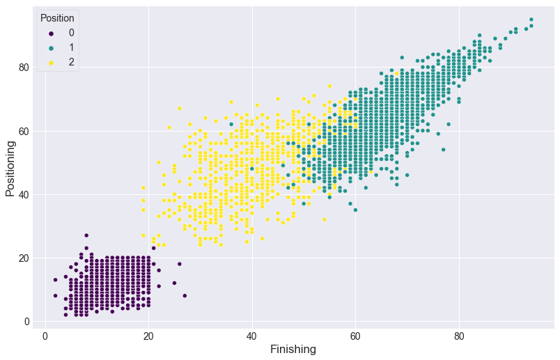

```python
sns.scatterplot(data=df_pos, x='Finishing', y='Positioning', hue='Position', palette='viridis')
plt.show()
```

```python
df_pos = df_pos[~((df_pos['Position'] == 1) & (df_pos['Finishing'] > 30) & (df_pos['Positioning'] < 60))]
df_pos = df_pos[~((df_pos['Position'] == 2) & (df_pos['Finishing'] > 60) & (df_pos['Positioning'] < 80))]
df_pos = df_pos[~((df_pos['Position'] == 3) & (df_pos['Finishing'] < 45))]
df_pos = df_pos[~((df_pos['Position'] == 3) & (df_pos['Finishing'] < 60) & (df_pos['Positioning'] > 70))]
df_pos = df_pos[~((df_pos['Position'] == 2) & (df_pos['Finishing'] > 65) & (df_pos['Positioning'] > 70))]
```

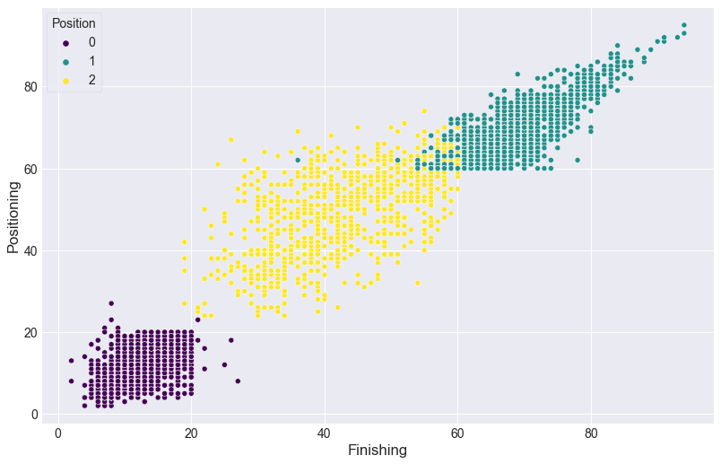

```python
sns.scatterplot(data=df_pos, x='Finishing', y='Positioning', hue='Position', palette='viridis')
plt.show()
```